# Resistance & recovery 4-sp communities: Analyze flow cytometry data

## Plot

Plot the preferred model against the data: growth on final day ~ heat duration + protegens present + community_expected_mu

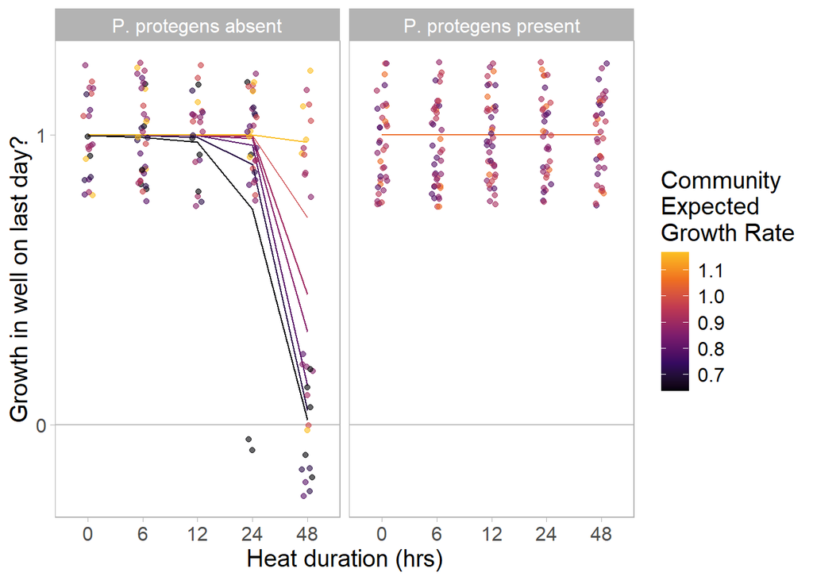

```r
# create data.frame for plotting
extinct.df <- cbind(extinct.df,
                    predicted = predict(ext_mod.exptmu_prot, type="response"))
# plot the predictions against the data
plot(ggplot(extinct.df,
        aes(x=as.factor(Heat),
            y=survived,
            colour=community_expected_mu,
            group=as.factor(community_expected_mu))) +
    facet_wrap(. ~ protegens,
               labeller = as_labeller(c(`0`="P. protegens absent",
                                        `1`="P. protegens present"))) +
    geom_hline(yintercept = 0, colour="grey") +
    geom_line(aes(y = predicted)) +
    geom_jitter(alpha=0.6, width=0.1, height = 0.25) +
      # would be nice to use beeswarm package but not sure how to do that as y is factorial here but numeric for the model predictions
    scale_y_continuous(breaks = c(0, 1)) +
    scale_colour_viridis_c(option = "inferno", end=0.85) +
    labs(x="Heat duration (hrs)",
         y="Growth in well on last day?", colour="Community\nExpected\nGrowth Rate"))
```

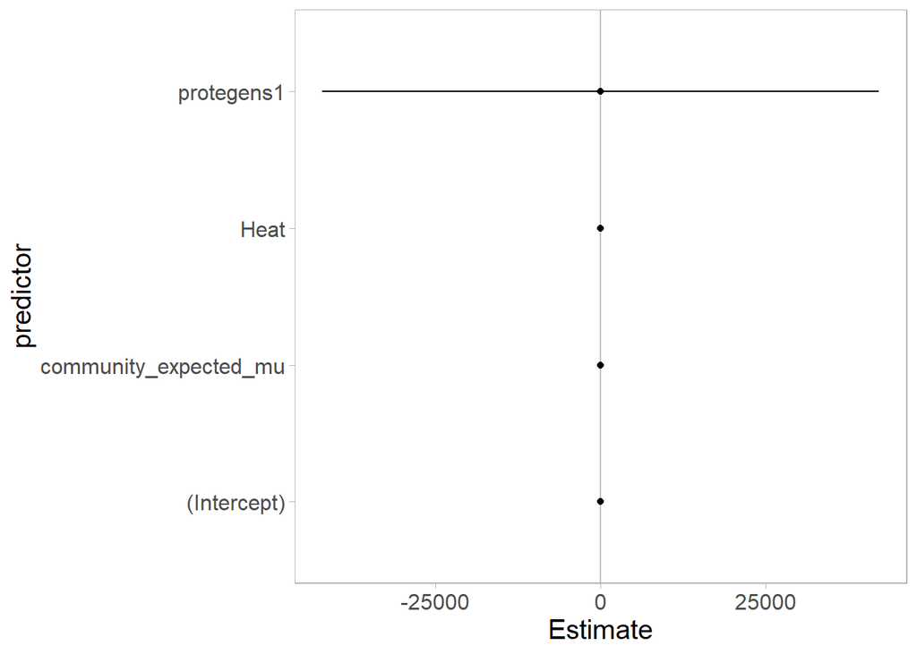

```r
# plot the effect sizes of the preferred model
extinct_forplot <- data.frame(confint(ext_mod.exptmu_prot))
colnames(extinct_forplot)[1:2] <- c("loCI", "hiCI")
extinct_forplot$predictor <- as.factor(rownames(extinct_forplot))
# protegens effect size is not significant and has giant CI that obscure other estimates
ggplot(extinct_forplot,
       aes(x = Estimate, y = predictor)) +
  geom_vline(xintercept = 0, colour="grey") +
  geom_point() +
  geom_errorbarh(aes(xmin = loCI, xmax = hiCI), height=0)
```

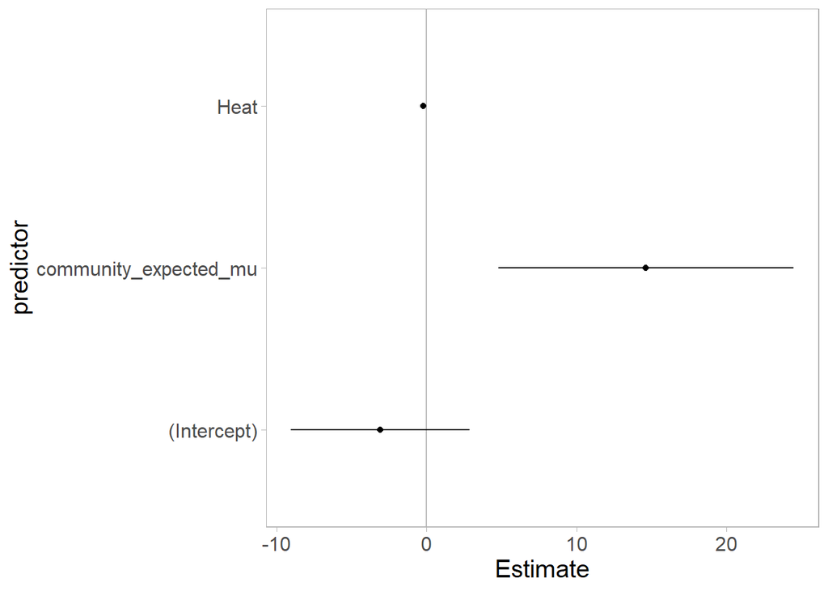

```r
# plot the effect sizes again without protegens
ggplot(extinct_forplot %>% filter(predictor != "protegens1"),
       aes(x = Estimate, y = predictor)) +
  geom_vline(xintercept = 0, colour="grey") +
  geom_point() +
  geom_errorbarh(aes(xmin = loCI, xmax = hiCI), height=0)
```

```r
# clean up
rm(ext_mod.heat, ext_mod.heat_plus_rich, ext_mod.heat_plus_resist, ext_mod.heat_plus_prot, ext_mod.heat_by_rich, ext_mod.heat_by_prot, ext_mod.heat_rich_prot, ext_mod.rich_heatXprot, ext_mod.expect_mu, ext_mod.averaged_mu, ext_mod.exptmu_prot, ext_mod.avemu_prot, extinct_forplot, ext_mod.exptmu_prot_resist, ext_mod.exptmuXprot, ext_mod.heatXexptmu_prot, ext_mod.heatXprot_exptmu, ext_mod.heatXprotXexptmu)
```

# Shannon diversity

How is community diversity impacted during and after heat? Here we will have to be mindful to control for inoculated community richness as a nuisance variable (i.e., because we will always expect to see (less) more diversity in communities that were inoculated with more (less) species. But this is just part of our experimental design; we’re not interested in this effect per se).

Let’s first plot the Shannon diversity directly to get an idea of what we’re dealing with:

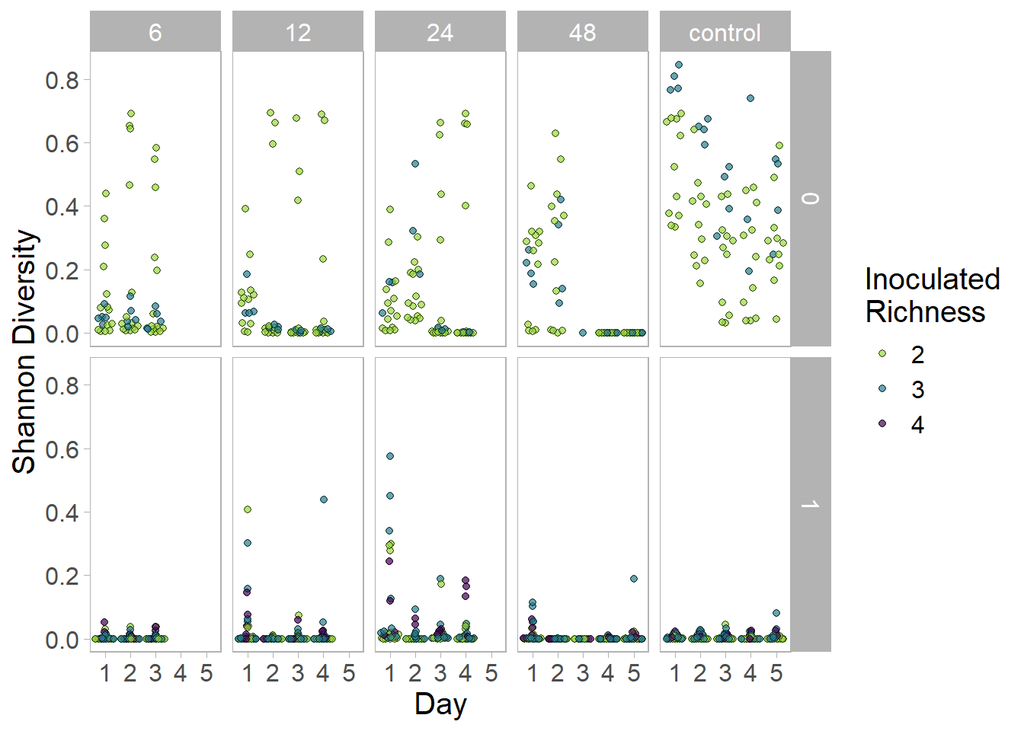

```r
ggplot(absDen_forFit %>% filter(CommRich > 1), # monocultures are meaningless for diversity
       aes(y=Diversity, x=Day, fill=as.factor(CommRich))) +
  facet_grid(protegens~as.factor(Heat)) +
  geom_quasirandom(alpha=0.7, pch=21) +
  scale_fill_viridis_d(option = "viridis", begin=0.85, end=0) +
  labs(y = "Shannon Diversity",
       fill = "Inoculated\nRichness")
```

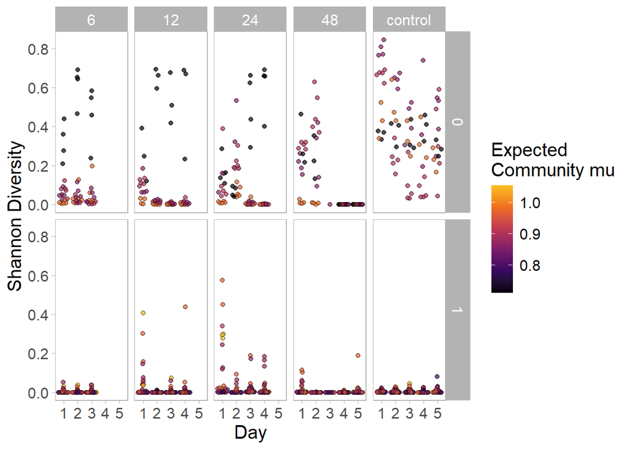

```r
ggplot(absDen_forFit %>% filter(CommRich > 1), # monocultures are meaningless for diversity
       aes(y=Diversity, x=Day, fill=community_expected_mu)) +
  facet_grid(protegens~as.factor(Heat)) +
  geom_quasirandom(alpha=0.7, pch=21) +
  scale_fill_viridis_c(option = "inferno", end=0.85) +
  labs(y = "Shannon Diversity",
       fill = "Expected\nCommunity mu")
```

## Choose GLM Family

Maddy and Gerard suggest that I use the full model to estimate effect size then emmeans to estimate the effect size post-hoc. I’m tailouring this analysis on the example script that Nico sent me (`Script_simplified for Hermina.R`).

One unique attribute of my experimental design is that the Day used as control differs with heat duration (e.g., last day of recovery for 6h heat duration is Day 3 but last day of recovery for 48h is Day 5). Our solution for this is to run separate models for each heat treatment with its respective controls (i.e., 4 models in total). To make sure that the effect sizes will be directly comparable across the models (especially with respect to the standard deviation), Gerard suggested that I scale the whole data prior to splitting it up into 4 (but not centering it as that will give me negative values that I can’t really use a ). Finally, if/when testing for significance it will then be necessary to control for multiple testing (e.g., using a Bonferroni correction).

Note that for diversity I am considering CommRich as a numeric (which assumes a linear effect of community richness, e.g., where 4 species is 2 * the effect of 2 species). Initially I tried playing around with CommRich as an ordered (& unordered) factor. But I found that `glmmTMB` was choosing to drop different predictors because it was upset that my model was overparameterized. This was particularly annoying as it was dropping the estimates for the control treatments…

The first thing we need to do is to pick which GLM family of distributions looks best for our data:

```r
# remove the monocultures from the data
diversity_forFit <- absDen_forFit %>% filter(CommRich > 1) %>% # diversity is nonsense for monocultures
                        select(-Total_density, -Conc_putida, -Conc_protegens, -Conc_grimontii, -Conc_veronii)

# scale the data by its standard deviation
diversity_forFit$Diversity_scale <- scale(diversity_forFit$Diversity,
                                          scale = sd(diversity_forFit$Diversity, na.rm =  TRUE),
                                          center = FALSE)

# the max re-scaled value is 5.38 and 38% of the data is 0's
# so try gamma and lognormal distributions (maybe also Gaussian just to check that it's a bad fit?)
summary(diversity_forFit$Diversity_scale)
```

```
##        V1
##  Min.   :0.00000
##  1st Qu.:0.00000
##  Median :0.01955
##  Mean   :0.45128
##  3rd Qu.:0.19557
##  Max.   :5.37608
##  NA's   :12
```

```r
sum(diversity_forFit$Diversity_scale == 0, na.rm = TRUE) / length(diversity_forFit$Diversity_scale)
```

```
## [1] 0.3850868
```

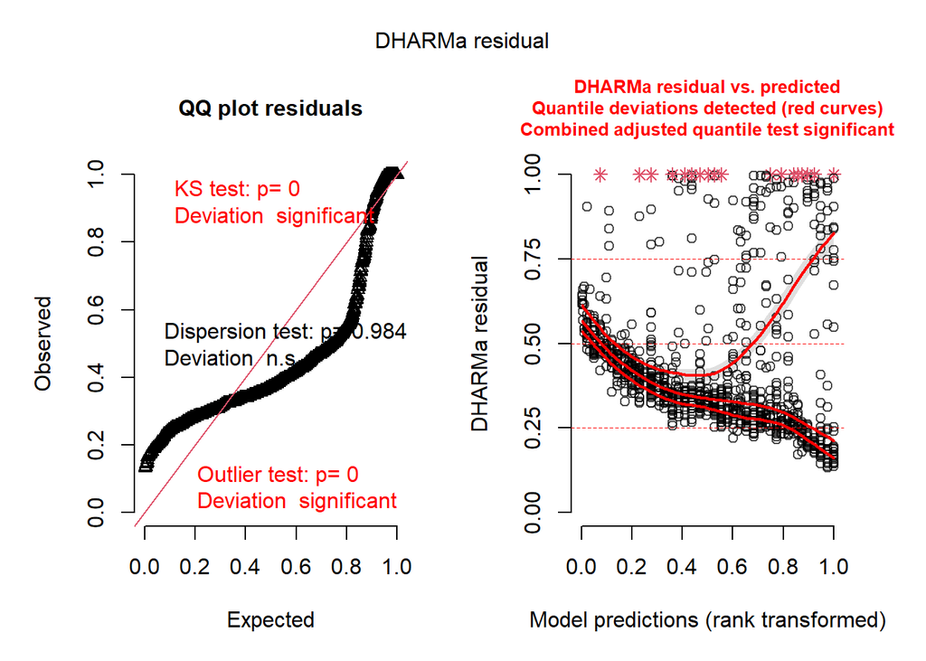

```
## Object of Class DHARMa with simulated residuals based on 250 simulations with refit = FALSE . See ?DHARMa::simulateResiduals for help.
##
## Scaled residual values: 1 0.196 0.26 0.992 1 0.2 0.208 0.944 0.208 0.248 1 0.18 0.26 0.224 1 0.212 0.212 0.244 1 0.256 ...
```

```r
# let's compare different GLM families
try_gaussian <- glmmTMB(Diversity_scale ~ CommRich:Day + Heat:Day + CommRich:Heat:Day,
                        data = diversity_forFit,
                        control = glmmTMBControl(optCtrl = list(iter.max = 10000,eval.max = 10000)))
simulateResiduals(fittedModel = try_gaussian, plot = TRUE)
```

```r
print("gamma family with zero-inflated model:")
```

```
## [1] "gamma family with zero-inflated model:"
```

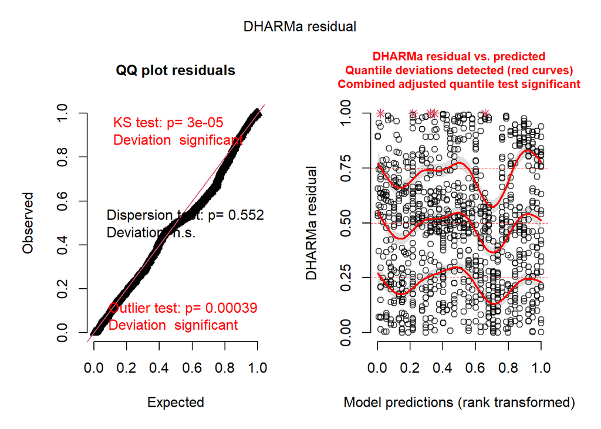

```
## Object of Class DHARMa with simulated residuals based on 250 simulations with refit = FALSE . See ?DHARMa::simulateResiduals for help.
##
## Scaled residual values: 0.952 0.42 0.3568358 0.944 0.94 0.3401457 0.3068186 0.88 0.58 0.1703229 0.988 0.456 0.612 0.512 0.964 0.1434111 0.532 0.428 0.984 0.424 ...
```

```r
try_gamma0 <- glmmTMB(Diversity_scale ~ CommRich:Day + Heat:Day + CommRich:Heat:Day,
                     data = diversity_forFit,
                     family = ziGamma,
                     ziformula = ~1, # this needs to be added because there are 0 values in the data
                     control = glmmTMBControl(optCtrl = list(iter.max = 10000,eval.max = 10000)))
simulateResiduals(fittedModel = try_gamma0, plot = TRUE)
```

```r
print("lognormal family with zero-inflated model:")
```

```
## [1] "lognormal family with zero-inflated model:"
```

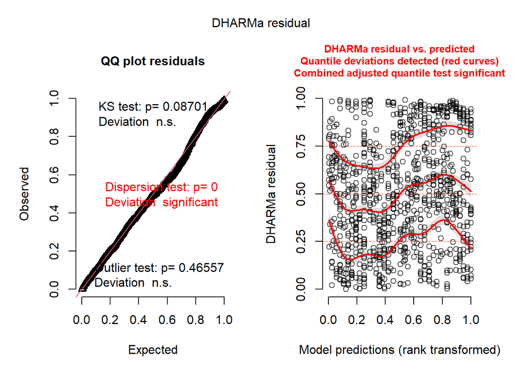

```
## Object of Class DHARMa with simulated residuals based on 250 simulations with refit = FALSE . See ?DHARMa::simulateResiduals for help.
##
## Scaled residual values: 0.944 0.392 0.160635 0.952 0.948 0.1410465 0.2099037 0.948 0.488 0.3268879 0.968 0.476 0.628 0.5 0.972 0.09914734 0.556 0.4 0.988 0.452 ...
```

```r
try_lognorm0 <- glmmTMB(Diversity_scale ~ CommRich:Day + Heat:Day + CommRich:Heat:Day,
                       data = diversity_forFit,
                       family = lognormal,
                       ziformula = ~1, # this needs to be added because there are 0 values in the data
                       control = glmmTMBControl(optCtrl = list(iter.max = 10000,eval.max = 10000)))
simulateResiduals(fittedModel = try_lognorm0, plot = TRUE)
```

```r
print("log(x+1) transformed data, lognormal family with zero-inflated model:")
```

```
## [1] "log(x+1) transformed data, lognormal family with zero-inflated model:"
```

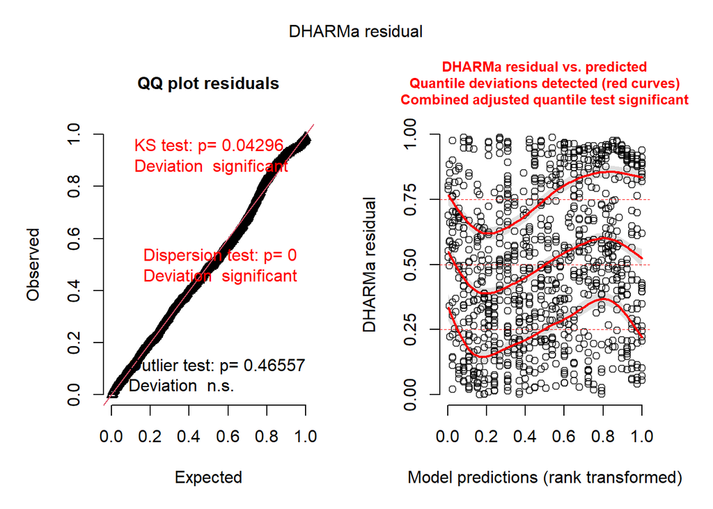

```
## Object of Class DHARMa with simulated residuals based on 250 simulations with refit = FALSE . See ?DHARMa::simulateResiduals for help.
##
## Scaled residual values: 0.932 0.38 0.160635 0.94 0.92 0.1410465 0.2099037 0.94 0.488 0.3268879 0.944 0.476 0.644 0.508 0.956 0.09914734 0.568 0.4 0.976 0.448 ...
```

```r
try_LOGlognorm0 <- glmmTMB(log(Diversity_scale+1) ~ CommRich:Day + Heat:Day + CommRich:Heat:Day,
                          data = diversity_forFit,
                          family = lognormal,
                          ziformula = ~1, # I'm keeping this as 0-inflated lognormal alone was already over-dispersed. So I want to see if the log(x+1) transformation sufficiently brings in the long tail.
                          control = glmmTMBControl(optCtrl = list(iter.max = 10000,eval.max = 10000)))
simulateResiduals(fittedModel = try_LOGlognorm0, plot = TRUE)
```

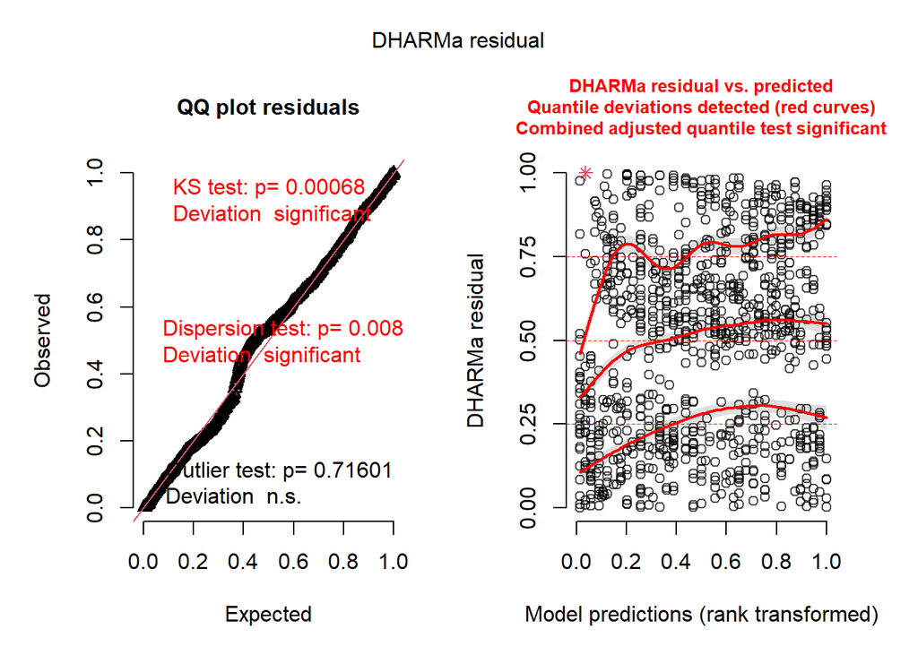

```
## Object of Class DHARMa with simulated residuals based on 250 simulations with refit = FALSE . See ?DHARMa::simulateResiduals for help.
##
## Scaled residual values: 0.9 0.484 0.02934308 0.888 0.932 0.001846165 0.1464347 0.844 0.524 0.04893932 0.928 0.545532 0.592 0.498831 0.964 0.08390474 0.62 0.436 0.972 0.496 ...
```

```r
try_negbinom <- glmmTMB(as.integer(Diversity_scale*1000) ~ CommRich:Day + Heat:Day + CommRich:Heat:Day,
                       data = diversity_forFit,
                       family = nbinom2,
                       control = glmmTMBControl(optCtrl = list(iter.max = 10000,eval.max = 10000)))
simulateResiduals(fittedModel = try_negbinom, plot = TRUE)
```

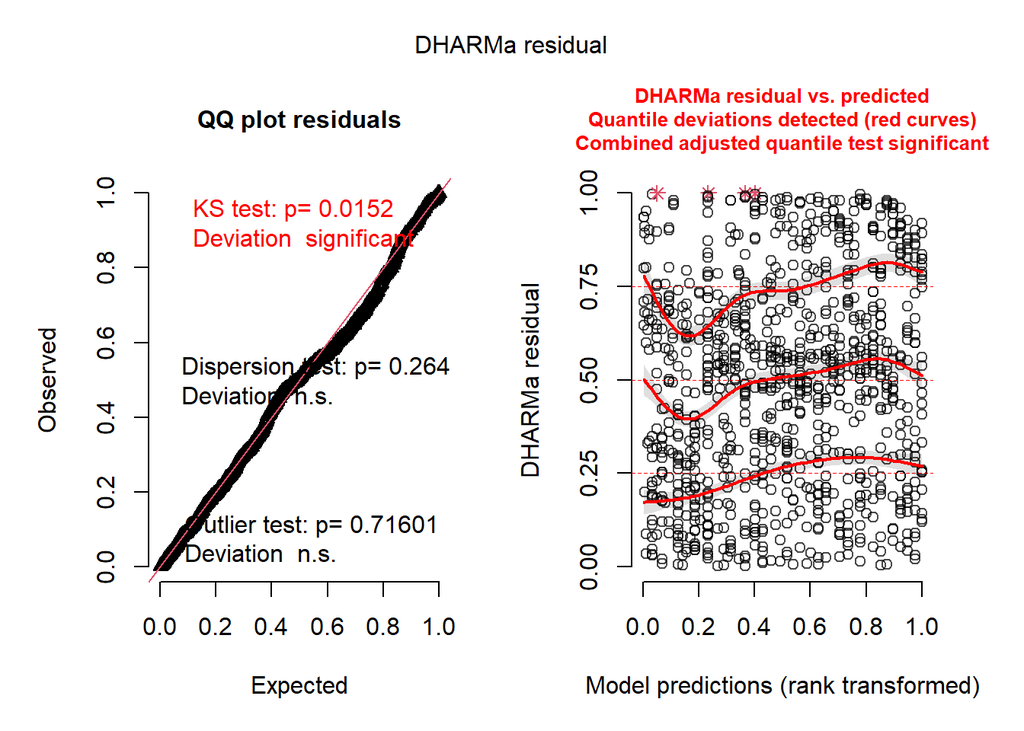

```
## Object of Class DHARMa with simulated residuals based on 250 simulations with refit = FALSE . See ?DHARMa::simulateResiduals for help.
##
## Scaled residual values: 0.968 0.4760399 0.09975181 0.944 0.96 0.1870824 0.1012531 0.856 0.524 0.2883702 0.972 0.488 0.5489878 0.472 0.972 0.2933996 0.576 0.4214444 0.968 0.48 ...
```

```r
try_negbinom0 <- glmmTMB(as.integer(Diversity_scale*1000) ~ CommRich:Day + Heat:Day + CommRich:Heat:Day,
                         data = diversity_forFit,
                         family = nbinom2,
                         ziformula = ~1, # try zero inflated distribution
                         control = glmmTMBControl(optCtrl = list(iter.max = 10000,eval.max = 10000)))
simulateResiduals(fittedModel = try_negbinom0, plot = TRUE)
```

```
## DHARMa:testOutliers with type = binomial may have inflated Type I error rates for integer-valued distributions. To get a more exact result, it is recommended to re-run testOutliers with type = 'bootstrap'. See ?testOutliers for details
```

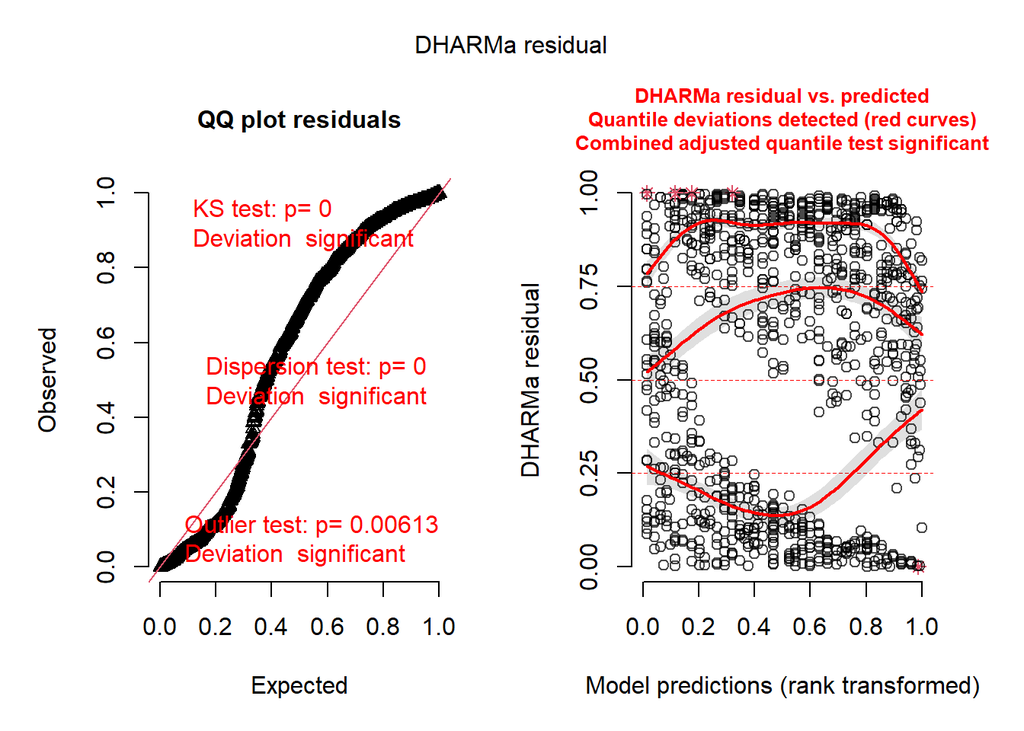

```
## Object of Class DHARMa with simulated residuals based on 250 simulations with refit = FALSE . See ?DHARMa::simulateResiduals for help.
##
## Scaled residual values: 0.992 0.4616676 0.04975974 0.968 0.98 0.001601337 0.06714782 0.96 0.5715112 0.02849031 0.98 0.5892411 0.78 0.728 0.984 0.0152989 0.78 0.332584 0.984 0.4979502 ...
```

```r
try_poisson <- glmmTMB(as.integer(Diversity_scale*1000) ~ CommRich:Day + Heat:Day + CommRich:Heat:Day,
                         data = diversity_forFit,
                         family = genpois,
                         control = glmmTMBControl(optCtrl = list(iter.max = 10000,eval.max = 10000)))
simulateResiduals(fittedModel = try_poisson, plot = TRUE)
```

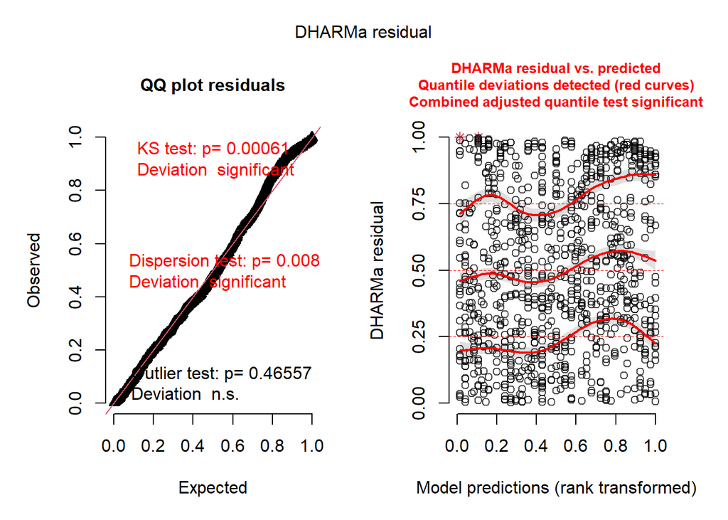

```
## Object of Class DHARMa with simulated residuals based on 250 simulations with refit = FALSE . See ?DHARMa::simulateResiduals for help.
##
## Scaled residual values: 0.956 0.3819737 0.211971 0.968 0.964 0.01318631 0.2743196 0.924 0.3770803 0.244544 0.972 0.388 0.584 0.4491087 0.96 0.05561836 0.5923928 0.3206311 0.972 0.356 ...
```

```r
try_poisson0 <- glmmTMB(as.integer(Diversity_scale*1000) ~ CommRich:Day + Heat:Day + CommRich:Heat:Day,
                         data = diversity_forFit,
                         family = genpois,
                         ziformula = ~1, # try zero inflated distribution
                         control = glmmTMBControl(optCtrl = list(iter.max = 10000,eval.max = 10000)))
simulateResiduals(fittedModel = try_poisson0, plot = TRUE)
```

```r
################################################

# I would generally prefer to use a zero inflated distribution but those are annoying to calculate effect sizes for (by posthoc emmeans). So let's do the classic hack and
  # find the smallest non-zero value in the rescaled diversity estimate
smallest_diversity <- min(diversity_forFit$Diversity_scale[diversity_forFit$Diversity_scale != 0], na.rm=TRUE)
# now add 1/100th of that value to all the diversity estimates and re-do the fit for the family that looked best above
diversity_forFit$Diversity_scalePLUSepsilon <- diversity_forFit$Diversity_scale + smallest_diversity/100

print("data transformed (D + epsilon), lognormal family:")
```

```
## [1] "data transformed (D + epsilon), lognormal family:"
```

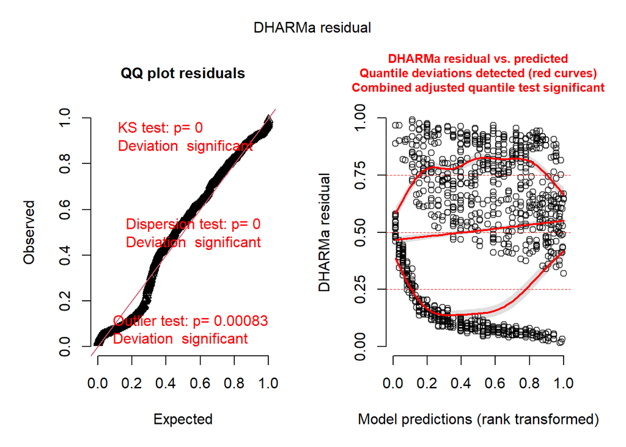

```
## Object of Class DHARMa with simulated residuals based on 250 simulations with refit = FALSE . See ?DHARMa::simulateResiduals for help.
##
## Scaled residual values: 0.912 0.444 0.072 0.932 0.908 0.04 0.044 0.868 0.48 0.028 0.904 0.472 0.608 0.576 0.9 0.056 0.576 0.34 0.88 0.444 ...
```

```r
# this looks just awful:
try_lognorm_plusE <- glmmTMB(Diversity_scalePLUSepsilon ~ CommRich:Day + Heat:Day + CommRich:Heat:Day,
                             data = diversity_forFit,
                             family = lognormal,
                             control = glmmTMBControl(optCtrl = list(iter.max = 10000,eval.max = 10000)))
simulateResiduals(fittedModel = try_lognorm_plusE, plot = TRUE)
```

```
## qu = 0.25, log(sigma) = -2.614364 : outer Newton did not converge fully.
```

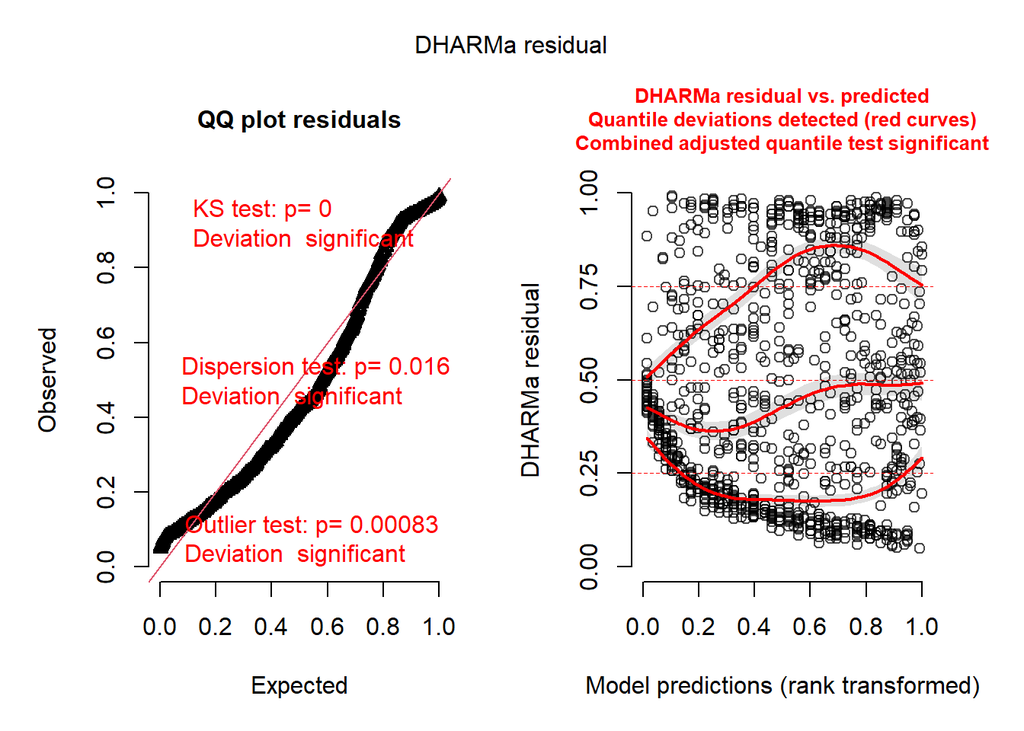

```
## Object of Class DHARMa with simulated residuals based on 250 simulations with refit = FALSE . See ?DHARMa::simulateResiduals for help.
##
## Scaled residual values: 0.96 0.196 0.112 0.972 0.944 0.072 0.088 0.936 0.288 0.052 0.968 0.32 0.544 0.436 0.956 0.084 0.524 0.204 0.956 0.256 ...
```

```r
#Let's see if we can make things better in any way by using a log transformation? (this model looked the best with zero-inflation above)
try_lognorm_logPLUSe <- glmmTMB(log(Diversity_scale+1+smallest_diversity) ~ CommRich:Day + Heat:Day + CommRich:Heat:Day,
                          data = diversity_forFit,
                          family = lognormal,
                          control = glmmTMBControl(optCtrl = list(iter.max = 10000,eval.max = 10000)))
simulateResiduals(fittedModel = try_lognorm_logPLUSe, plot = TRUE)
```

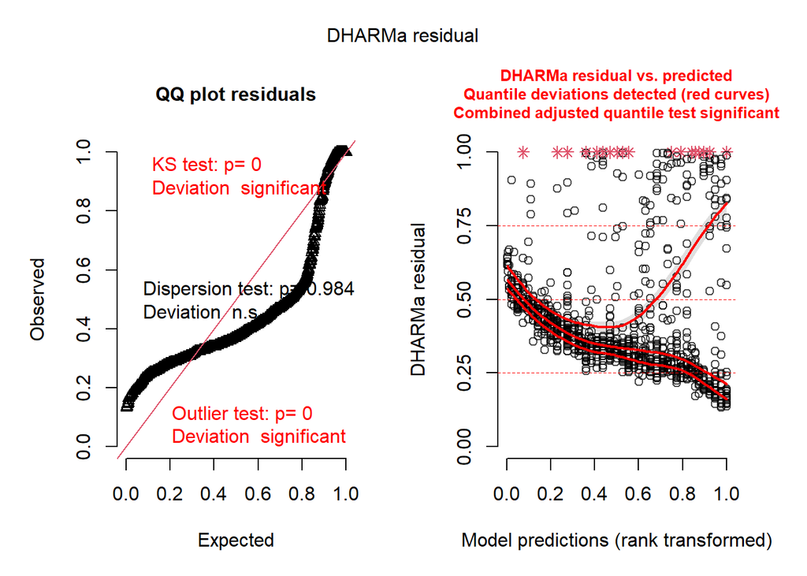

```
## Object of Class DHARMa with simulated residuals based on 250 simulations with refit = FALSE . See ?DHARMa::simulateResiduals for help.
##
## Scaled residual values: 1 0.196 0.26 0.992 1 0.2 0.208 0.944 0.208 0.248 1 0.18 0.26 0.224 1 0.212 0.212 0.244 1 0.256 ...
```

```r
# let's just try other families...
try_gaussian_plusE <- glmmTMB(Diversity_scalePLUSepsilon ~ CommRich:Day + Heat:Day + CommRich:Heat:Day,
                        data = diversity_forFit,
                        control = glmmTMBControl(optCtrl = list(iter.max = 10000,eval.max = 10000)))
simulateResiduals(fittedModel = try_gaussian_plusE, plot = TRUE)
```

```r
print("data transformed (D + epsilon), gamma family:")
```

```
## [1] "data transformed (D + epsilon), gamma family:"
```

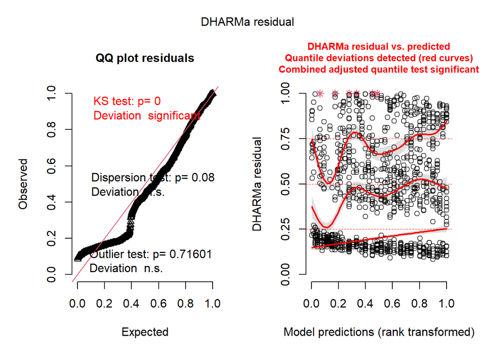

```
## Object of Class DHARMa with simulated residuals based on 250 simulations with refit = FALSE . See ?DHARMa::simulateResiduals for help.
##
## Scaled residual values: 0.932 0.376 0.156 0.88 0.916 0.104 0.152 0.864 0.42 0.108 0.928 0.38 0.516 0.48 0.884 0.104 0.512 0.364 0.944 0.408 ...
```

```r
try_gamma_plusE <- glmmTMB(Diversity_scalePLUSepsilon ~ CommRich:Day + Heat:Day + CommRich:Heat:Day,
                     data = diversity_forFit,
                     family = Gamma,
                     control = glmmTMBControl(optCtrl = list(iter.max = 10000,eval.max = 10000)))
simulateResiduals(fittedModel = try_gamma_plusE, plot = TRUE)
```

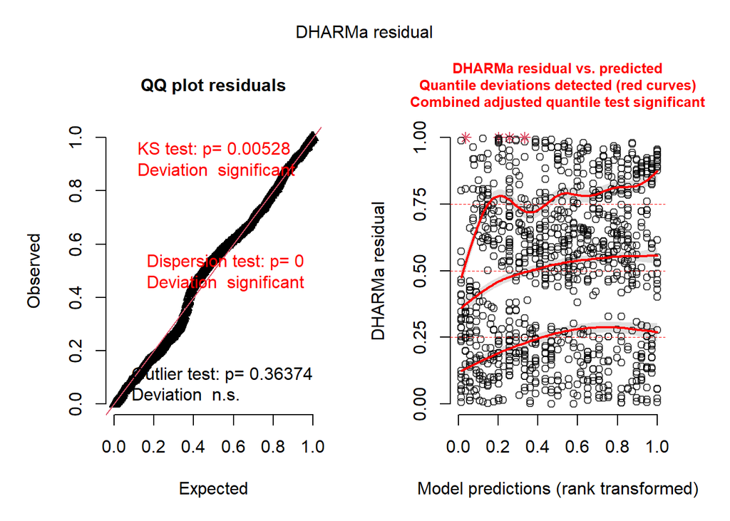

```
## Object of Class DHARMa with simulated residuals based on 250 simulations with refit = FALSE . See ?DHARMa::simulateResiduals for help.
##
## Scaled residual values: 0.888 0.4291341 0.02065348 0.936 0.952 0.05675836 0.05408069 0.876 0.512 0.04733732 0.98 0.464 0.592 0.616 0.956 0.00626431 0.596 0.443546 0.976 0.4538491 ...
```

```r
try_negbinom_plusE <- glmmTMB(as.integer(Diversity_scalePLUSepsilon*1000) ~ CommRich:Day + Heat:Day + CommRich:Heat:Day,
                       data = diversity_forFit,
                       family = nbinom2,
                       control = glmmTMBControl(optCtrl = list(iter.max = 10000,eval.max = 10000)))
simulateResiduals(fittedModel = try_negbinom_plusE, plot = TRUE)
```

```
## DHARMa:testOutliers with type = binomial may have inflated Type I error rates for integer-valued distributions. To get a more exact result, it is recommended to re-run testOutliers with type = 'bootstrap'. See ?testOutliers for details
```

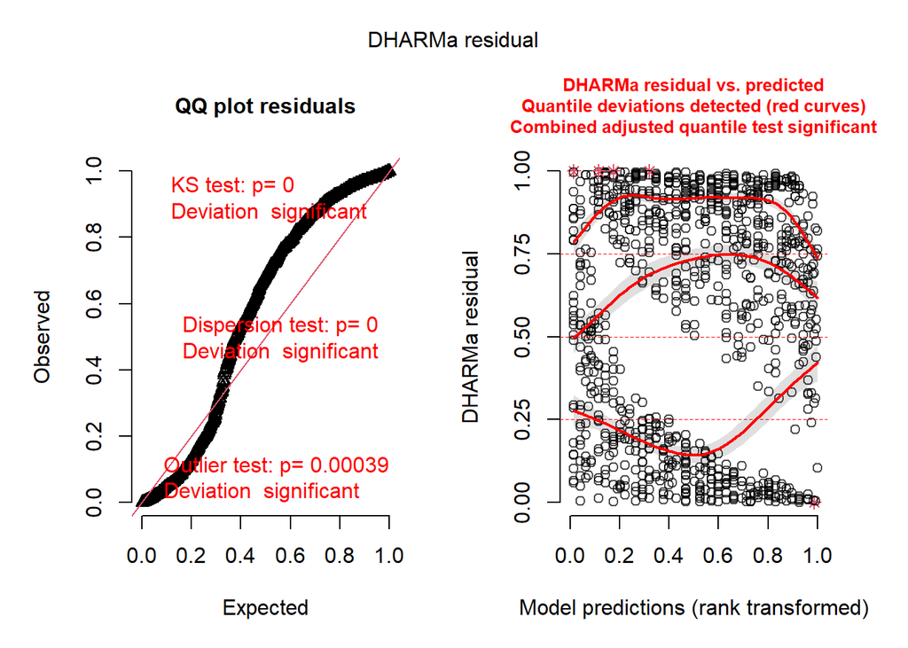

```
## Object of Class DHARMa with simulated residuals based on 250 simulations with refit = FALSE . See ?DHARMa::simulateResiduals for help.
##
## Scaled residual values: 0.992 0.4616676 0.04975974 0.968 0.98 0.001601337 0.06714782 0.96 0.5715112 0.02849031 0.98 0.5892411 0.78 0.728 0.984 0.0152989 0.78 0.331438 0.984 0.496 ...
```

```r
try_poisson_plusE <- glmmTMB(as.integer(Diversity_scalePLUSepsilon*1000) ~ CommRich:Day + Heat:Day + CommRich:Heat:Day,
                         data = diversity_forFit,
                         family = genpois,
                         control = glmmTMBControl(optCtrl = list(iter.max = 10000,eval.max = 10000)))
simulateResiduals(fittedModel = try_poisson_plusE, plot = TRUE)
```

```r
# let's check this with AIC and BIC
AIC(try_gaussian, try_gamma0, try_lognorm0, try_LOGlognorm0,
    try_negbinom, try_negbinom0, try_poisson, try_poisson0, try_lognorm_plusE, try_lognorm_logPLUSe, try_gaussian_plusE, try_gamma_plusE, try_negbinom_plusE, try_poisson_plusE) %>% arrange(AIC)
```

|  | df | AIC |
| --- | --- | --- |
| try_lognorm_plusE | 11 | -4098.909 |
| try_gamma_plusE | 11 | -3956.811 |
| try_lognorm_logPLUSe | 11 | -2127.029 |
| try_LOGlognorm0 | 12 | 1099.617 |
| try_lognorm0 | 12 | 1516.651 |
| try_gamma0 | 12 | 1612.662 |
| try_gaussian | 11 | 2700.521 |
| try_gaussian_plusE | 11 | 2700.521 |
| try_poisson0 | 12 | 9569.842 |
| try_negbinom0 | 12 | 9697.691 |

[output cut: 4 more lines]

```r
BIC(try_gaussian, try_gamma0, try_lognorm0, try_LOGlognorm0,
    try_negbinom, try_negbinom0, try_poisson, try_poisson0, try_lognorm_plusE, try_lognorm_logPLUSe, try_gaussian_plusE, try_gamma_plusE, try_negbinom_plusE, try_poisson_plusE) %>% arrange(BIC)
```

|  | df | BIC |
| --- | --- | --- |
| try_lognorm_plusE | 11 | -4045.293 |
| try_gamma_plusE | 11 | -3903.195 |
| try_lognorm_logPLUSe | 11 | -2073.413 |
| try_LOGlognorm0 | 12 | 1158.108 |
| try_lognorm0 | 12 | 1575.142 |
| try_gamma0 | 12 | 1671.152 |
| try_gaussian | 11 | 2754.137 |
| try_gaussian_plusE | 11 | 2754.137 |
| try_poisson0 | 12 | 9628.332 |
| try_negbinom0 | 12 | 9756.181 |

[output cut: 4 more lines]

```r
# clean up
rm(try_gaussian, try_gamma0, try_lognorm0, try_LOGlognorm0, try_negbinom, try_negbinom0, try_poisson, try_poisson0, try_lognorm_plusE, try_lognorm_logPLUSe, try_gaussian_plusE, try_gamma_plusE, try_negbinom_plusE, try_poisson_plusE, smallest_diversity)
```

For this data I would generally prefer to use one of the zero inflated distributions but we are interested in the effect sizes (emmeans & posthoc analyses). The problem with the zero inflated distribution is that it leads to very confusing looking effect sizes when I do the downstream analyses. This is because the effect sizes are split up over the conditional and the zero-inflated parts of the model. The overall effect size is: (1 - zi)*(cond mean). See [this stackover flow thread](https://stackoverflow.com/questions/62351158/contrasts-with-zero-inflated-glmmtmb). The practical problem is that it just looks really weird for this data.

To get around this issue, I have transformed the re-scaled data to add a small value (`min(rescaled diversity)/100`) to all diversity estimates such that we remove the zero’s. This way we will no longer need to use a zero-inflated part in the model and the effect sizes will be simpler to explain. (Especially because I think I am losing a lot of power for the 48h treatment as a result of almost everything literally being 0.)

My final decision is to use the $D + \epsilon$ transformed data and a lognormal family of distributions. It doesn’t have the best residuals but it strikes the right compromise of *a priori* justifiable as well as useful and interpretable for the analysis we’re interested in.

Finally, note that in the model fitting above I consider Day as a numeric predictor. This is because I want to decide on the GLM family by considering the complete data. (& I was having problems with Day as an un/ordered factor…)

## Compare fit of different models to data subsets

For the rest of the analysis below, I consider the effect of day (which is called `Trtmt_Day`) as a factor representing either resistance (i.e., on the last day of heat) or recovery. To do this I need to subset the data to include only resistance, 1st day post-heat, and last day post-heat for the heat treatment. And I need to keep exactly the same days of the control treatment. I create this data subset for each heat treatment duration (so 4 data subsets in total).

We want to find which model is the best fit for all the data subsets.

Note that it’s not possible to fit any models with protegens present **and** heat resistant both as predictors!!

```r
# a hacky function to get the number of parameters in the model
npar_of_glmmTMB_fit <- function(modfit)
  length(modfit$fit$parfull)

# a function to fit the different models to the subsetted data:
fit_diversity_models <- function(data_subset) {
  # create list for output
  output.ls <- list()

  # this is the simplest model. I'm fitting it to check for colinearity
  output.ls[["simple"]] <- glmmTMB(Diversity_scalePLUSepsilon ~ CommRich + Heat + Trtmt_Day + protegens + community_expected_mu,
                               data = data_subset,
                               family = lognormal,
                               control = glmmTMBControl(optCtrl = list(iter.max = 500000,eval.max = 500000)))
  # this is another simple model to check for colinearity
  output.ls[["simple resist"]] <- glmmTMB(Diversity_scalePLUSepsilon ~ CommRich + Heat + Trtmt_Day + community_expected_mu + resistant,
                               data = data_subset,
                               family = lognormal,
                               control = glmmTMBControl(optCtrl = list(iter.max = 500000,eval.max = 500000)))
  # this is our null model:
  output.ls[["H0"]] <- glmmTMB(Diversity_scalePLUSepsilon ~ CommRich + Heat*Trtmt_Day,
                               data = data_subset,
                               family = lognormal,
                               control = glmmTMBControl(optCtrl = list(iter.max = 500000,eval.max = 500000)))
  # this is another null model just to confirm that CommRich has NO interactions with heat
  output.ls[["H0: *CommRich"]] <- glmmTMB(Diversity_scalePLUSepsilon ~ CommRich*Heat*Trtmt_Day,
                                          data = data_subset,
                                          family = lognormal,
                                          control = glmmTMBControl(optCtrl = list(iter.max = 500000,eval.max = 500000)))

  output.ls[["+resist"]] <- glmmTMB(Diversity_scalePLUSepsilon ~ CommRich + Heat*Trtmt_Day + resistant,
                                   data = data_subset,
                                   family = lognormal,
                                   control = glmmTMBControl(optCtrl = list(iter.max = 500000,eval.max = 500000)))

  output.ls[["*resist"]] <- glmmTMB(Diversity_scalePLUSepsilon ~ CommRich + Heat*Trtmt_Day*resistant,
                                   data = data_subset,
                                   family = lognormal,
                                   control = glmmTMBControl(optCtrl = list(iter.max = 500000,eval.max = 500000)))

  output.ls[["+prot"]] <- glmmTMB(Diversity_scalePLUSepsilon ~ CommRich + Heat*Trtmt_Day + protegens,
                                  data = data_subset,
                                  family = lognormal,
                                  control = glmmTMBControl(optCtrl = list(iter.max = 500000,eval.max = 500000)))

  output.ls[["*prot"]] <- glmmTMB(Diversity_scalePLUSepsilon ~ CommRich + Heat*Trtmt_Day*protegens,
                                  data = data_subset,
                                  family = lognormal,
                                  control = glmmTMBControl(optCtrl = list(iter.max = 500000,eval.max = 500000)))

  output.ls[["+mu"]] <- glmmTMB(Diversity_scalePLUSepsilon ~ CommRich + Heat*Trtmt_Day + community_expected_mu,
                                data = data_subset,
                                family = lognormal,
                                control = glmmTMBControl(optCtrl = list(iter.max = 500000,eval.max = 500000)))

  output.ls[["*mu"]] <- glmmTMB(Diversity_scalePLUSepsilon ~ CommRich + Heat*Trtmt_Day*community_expected_mu,
                                data = data_subset,
                                family = lognormal,
                                control = glmmTMBControl(optCtrl = list(iter.max = 500000,eval.max = 500000)))

  output.ls[["+prot +mu"]] <- glmmTMB(Diversity_scalePLUSepsilon ~ CommRich + Heat*Trtmt_Day + protegens + community_expected_mu,
                                      data = data_subset,
                                      family = lognormal,
                                      control = glmmTMBControl(optCtrl = list(iter.max = 500000,eval.max = 500000)))

  output.ls[["+resist +mu"]] <- glmmTMB(Diversity_scalePLUSepsilon ~ CommRich + Heat*Trtmt_Day + resistant + community_expected_mu,
                                        data = data_subset,
                                        family = lognormal,
                                        control = glmmTMBControl(optCtrl = list(iter.max = 500000,eval.max = 500000)))

  output.ls[["*prot +mu"]] <- glmmTMB(Diversity_scalePLUSepsilon ~ CommRich + Heat*Trtmt_Day*protegens + community_expected_mu,
                                      data = data_subset,
                                      family = lognormal,
                                      control = glmmTMBControl(optCtrl = list(iter.max = 500000,eval.max = 500000)))

  output.ls[["*prot + prot*mu"]] <- glmmTMB(Diversity_scalePLUSepsilon ~ CommRich + Heat*Trtmt_Day*protegens + protegens*community_expected_mu,
                                            data = data_subset,
                                            family = lognormal,
                                            control = glmmTMBControl(optCtrl = list(iter.max = 500000,eval.max = 500000)))

  output.ls[["*mu +prot"]] <- glmmTMB(Diversity_scalePLUSepsilon ~ CommRich + Heat*Trtmt_Day*community_expected_mu + protegens,
                                      data = data_subset,
                                      family = lognormal,
                                      control = glmmTMBControl(optCtrl = list(iter.max = 500000,eval.max = 500000)))

  output.ls[["*mu + mu*prot"]] <- glmmTMB(Diversity_scalePLUSepsilon ~ CommRich + Heat*Trtmt_Day*community_expected_mu + community_expected_mu*protegens,
                                          data = data_subset,
                                          family = lognormal,
                                          control = glmmTMBControl(optCtrl = list(iter.max = 500000,eval.max = 500000)))

  output.ls[["*mu +resist"]] <- glmmTMB(Diversity_scalePLUSepsilon ~ CommRich + Heat*Trtmt_Day*community_expected_mu + resistant,
                                        data = data_subset,
                                        family = lognormal,
                                        control = glmmTMBControl(optCtrl = list(iter.max = 500000,eval.max = 500000)))

  output.ls[["*mu + mu*resist"]] <- glmmTMB(Diversity_scalePLUSepsilon ~ CommRich + Heat*Trtmt_Day*community_expected_mu + community_expected_mu*resistant,
                                            data = data_subset,
                                            family = lognormal,
                                            control = glmmTMBControl(optCtrl = list(iter.max = 500000,eval.max = 500000)))

  output.ls[["*resist +mu"]] <- glmmTMB(Diversity_scalePLUSepsilon ~ CommRich + Heat*Trtmt_Day*resistant + community_expected_mu,
                                        data = data_subset,
                                        family = lognormal,
                                        control = glmmTMBControl(optCtrl = list(iter.max = 500000,eval.max = 500000)))

  output.ls[["*resist + resist*mu"]] <- glmmTMB(Diversity_scalePLUSepsilon ~ CommRich + Heat*Trtmt_Day*resistant + resistant*community_expected_mu,
                                                data = data_subset,
                                                family = lognormal,
                                                control = glmmTMBControl(optCtrl = list(iter.max = 500000,eval.max = 500000)))

  output.ls[["*prot*mu"]] <- glmmTMB(Diversity_scalePLUSepsilon ~ CommRich + Heat*Trtmt_Day*protegens*community_expected_mu,
                                     data = data_subset,
                                     family = lognormal,
                                     control = glmmTMBControl(optCtrl = list(iter.max = 500000,eval.max = 500000)))
  output.ls[["*mu*resist"]] <- glmmTMB(Diversity_scalePLUSepsilon ~ CommRich + Heat*Trtmt_Day*community_expected_mu*resistant,
                                       data = data_subset,
                                       family = lognormal,
                                       control = glmmTMBControl(optCtrl = list(iter.max = 500000,eval.max = 500000)))

  return(output.ls)
}

# a function to plot model predictions against the data
  # INOCULATED COMMUNITY RICHNESS is plotted as different colours
plot_model_pred.CommRich <- function(mod_list, mod_name){
  # create data.frame for plotting
  divers_predict <- cbind(mod_list[[mod_name]]$frame,
                          predicted=predict(mod_list[[mod_name]], type="response"))
  # change the first column name for easier plotting
  colnames(divers_predict)[1] <- "observed"
  # create the plot
  out <- ggplot(divers_predict,
                aes(x=Trtmt_Day, y=observed, colour=as.factor(CommRich))) +
         facet_grid(protegens~Heat) +
         geom_jitter(alpha=0.4) +
         geom_line(aes(y=predicted, group=as.factor(CommRich))) +
         scale_y_log10() +
         scale_colour_viridis_d(option = "viridis", begin=0.1, end=0.85) +
         labs(y="Shannon diversity (rescaled)",
              colour="CommRich",
              title=paste(mod_name, "model predictions"))
  return(out)
  rm(divers_predict)
}

# a function to plot model predictions against the data
  # EXPECTED COMMUNITY MU is plotted as different colours
plot_model_pred.MU <- function(mod_list, mod_name){
  # create data.frame for plotting
  divers_predict <- cbind(mod_list[[mod_name]]$frame,
                          predicted=predict(mod_list[[mod_name]], type="response"))
  # change the first column name for easier plotting
  colnames(divers_predict)[1] <- "observed"
  # create the plot
  out <- ggplot(divers_predict,
                aes(x=Trtmt_Day, y=observed,
                    colour=community_expected_mu, group=as.factor(community_expected_mu))) +
         facet_grid(protegens~Heat) +
         geom_jitter(alpha=0.4) +
         geom_line(aes(y=predicted)) +
         scale_y_log10() +
         scale_colour_viridis_c(option = "inferno", end=0.85) +
         labs(y="Shannon diversity (rescaled)",
              colour="Expected\nCommunity mu",
              title=paste(mod_name, "model predictions"))
  return(out)
  rm(divers_predict)
}

####################
# 6h heat duration
####################
# grab just the treatment with its associated control data
diversity_6h <- rbind(diversity_forFit %>% filter(Heat == "6"),
                      diversity_forFit %>% filter(Heat == "control", Day < 4))
# create a column for last day of heat, first day of recovery, and last day of recovery
diversity_6h$Trtmt_Day <- "resist"
diversity_6h$Trtmt_Day[diversity_6h$Day == 2] <- "recov_1"
diversity_6h$Trtmt_Day[diversity_6h$Day == 3] <- "recov_2"

# fit different models:
div_mods6h <- fit_diversity_models(diversity_6h)

# check the simplest possible models for multicolinearity
check_collinearity(div_mods6h[["simple"]])
```

| Term | VIF | VIF_CI_low | VIF_CI_high | SE_factor | Tolerance | Tolerance_CI_low | Tolerance_CI_high |
| --- | --- | --- | --- | --- | --- | --- | --- |
| CommRich | 1.132152 | 1.046179 | 1.378187 | 1.064026 | 0.8832737 | 0.7255909 | 0.9558598 |
| Heat | 1.146461 | 1.055510 | 1.386428 | 1.070729 | 0.8722497 | 0.7212780 | 0.9474091 |
| Trtmt_Day | 1.086431 | 1.019453 | 1.384025 | 1.042320 | 0.9204450 | 0.7225305 | 0.9809185 |
| protegens | 1.075527 | 1.014148 | 1.403198 | 1.037076 | 0.9297768 | 0.7126577 | 0.9860497 |
| community_expected_mu | 1.094804 | 1.023873 | 1.376482 | 1.046329 | 0.9134056 | 0.7264899 | 0.9766836 |

```r
check_collinearity(div_mods6h[["simple resist"]])
```

| Term | VIF | VIF_CI_low | VIF_CI_high | SE_factor | Tolerance | Tolerance_CI_low | Tolerance_CI_high |
| --- | --- | --- | --- | --- | --- | --- | --- |
| CommRich | 1.211099 | 1.100676 | 1.442636e+00 | 1.100499 | 0.8256963 | 6.931753e-01 | 0.9085327 |
| Heat | 1.004687 | 1.000000 | 8.889379e+07 | 1.002341 | 0.9953344 | 1.124938e-08 | 1.0000000 |
| Trtmt_Day | 1.024747 | 1.000234 | 3.616256e+00 | 1.012298 | 0.9758504 | 2.765291e-01 | 0.9997660 |
| community_expected_mu | 2.446276 | 2.075944 | 2.944073e+00 | 1.564058 | 0.4087846 | 3.396654e-01 | 0.4817085 |
| resistant | 2.660074 | 2.247143 | 3.209727e+00 | 1.630973 | 0.3759294 | 3.115530e-01 | 0.4450095 |

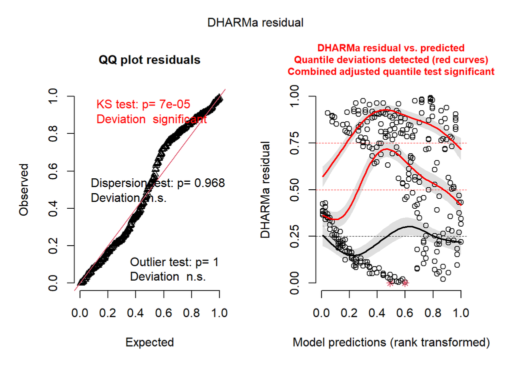

```
## Object of Class DHARMa with simulated residuals based on 250 simulations with refit = FALSE . See ?DHARMa::simulateResiduals for help.
##
## Scaled residual values: 0.06 0.72 0.456 0.956 0.088 0.156 0.768 0.852 0.352 0.892 0.812 0.64 0.248 0.804 0.696 0.728 0.216 0.872 0.284 0.916 ...
```

```r
# check the fit of the overall preferred model
simulateResiduals(fittedModel = div_mods6h[["*prot + prot*mu"]], plot = TRUE)
```

```r
summary(div_mods6h[["*prot + prot*mu"]])
```

```
##  Family: lognormal  ( log )
## Formula:
## Diversity_scalePLUSepsilon ~ CommRich + Heat * Trtmt_Day * protegens +
##     protegens * community_expected_mu
## Data: data_subset
##
##       AIC       BIC    logLik -2*log(L)  df.resid
##     -1202     -1143       617     -1234       280
##
##
## Dispersion parameter for lognormal family (): 1.21
##
## Conditional model:
##                                        Estimate Std. Error z value Pr(>|z|)
## (Intercept)                            -1.12238    0.65007  -1.727  0.08425 .
## CommRich                                0.65806    0.07012   9.384  < 2e-16 ***
## Heatcontrol                             1.55744    0.17430   8.935  < 2e-16 ***
## Trtmt_Dayrecov_2                       -0.22741    0.20855  -1.090  0.27551
## Trtmt_Dayresist                         0.05919    0.19731   0.300  0.76419
## protegens                              -8.00074    1.08149  -7.398 1.38e-13 ***
## community_expected_mu                  -1.03511    0.66866  -1.548  0.12161
## Heatcontrol:Trtmt_Dayrecov_2           -0.28588    0.25017  -1.143  0.25314
## Heatcontrol:Trtmt_Dayresist             0.17917    0.22391   0.800  0.42360
## Heatcontrol:protegens                  -1.00383    0.34733  -2.890  0.00385 **
## Trtmt_Dayrecov_2:protegens              0.15475    0.36833   0.420  0.67438
## Trtmt_Dayresist:protegens               0.10914    0.35737   0.305  0.76006
## protegens:community_expected_mu         5.56391    1.17388   4.740 2.14e-06 ***
## Heatcontrol:Trtmt_Dayrecov_2:protegens  0.23599    0.49838   0.474  0.63584
## Heatcontrol:Trtmt_Dayresist:protegens  -0.07657    0.47374  -0.162  0.87160
## ---
## Signif. codes:  0 '***' 0.001 '**' 0.01 '*' 0.05 '.' 0.1 ' ' 1
```

```r
# print a summary table of the model fits
data.frame(pars = sapply(div_mods6h, npar_of_glmmTMB_fit),
                           AIC = sapply(div_mods6h, AIC),
                           AICc = sapply(div_mods6h, AICc),
                           BIC = sapply(div_mods6h, BIC)) %>%
                    mutate(dAIC = min(AIC)-AIC,
                           dAICc = min(AICc)-AICc,
                           dBIC = min(BIC)-BIC) %>% arrange(BIC)
```

|  | pars | AIC | AICc | BIC | dAIC | dAICc | dBIC |
| --- | --- | --- | --- | --- | --- | --- | --- |
| *prot*mu | 26 | -1240.2635 | -1235.0442 | -1144.3141 | 0.00000 | 0.00000 | 0.000000 |
| *prot + prot*mu | 16 | -1202.0247 | -1200.0748 | -1142.9789 | -38.23882 | -34.96931 | -1.335227 |
| simple | 8 | -1165.2569 | -1164.7552 | -1135.7341 | -75.00655 | -70.28896 | -8.580079 |
| +prot | 9 | -1167.8733 | -1167.2439 | -1134.6600 | -72.39021 | -67.80025 | -9.654102 |
| *mu + mu*prot | 16 | -1193.5810 | -1191.6312 | -1134.5353 | -46.68245 | -43.41294 | -9.778860 |
| *prot | 14 | -1182.1126 | -1180.6180 | -1130.4476 | -58.15085 | -54.42619 | -13.866541 |
| +prot +mu | 10 | -1166.1512 | -1165.3793 | -1129.2476 | -74.11228 | -69.66488 | -15.066531 |
| *prot +mu | 15 | -1181.7127 | -1179.9984 | -1126.3573 | -58.55076 | -55.04572 | -17.956809 |
| *mu +prot | 15 | -1162.4117 | -1160.6974 | -1107.0563 | -77.85182 | -74.34678 | -37.257867 |
| simple resist | 8 | -999.0565 | -998.5548 | -969.5337 | -241.20694 | -236.48935 | -174.780472 |

[output cut: 12 more lines]

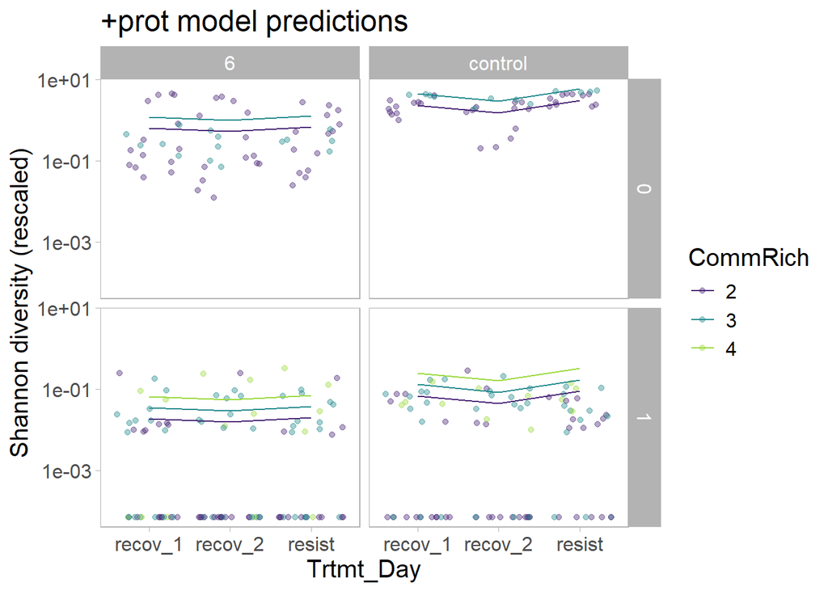

```r
# print some of the top model predictions
print(plot_model_pred.CommRich(mod_list=div_mods6h, mod_name="+prot"))
```

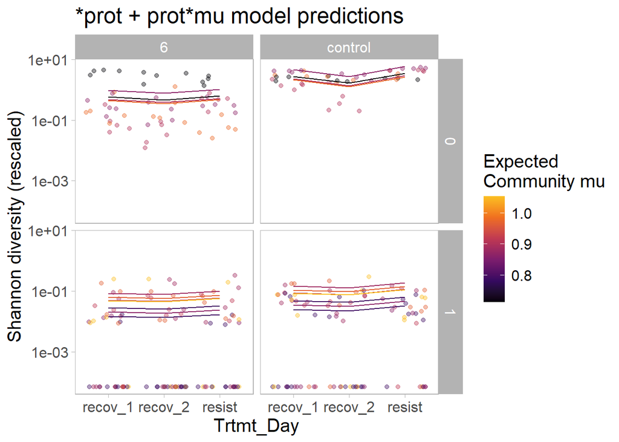

```r
print(plot_model_pred.MU(mod_list=div_mods6h, mod_name="*prot + prot*mu"))
```

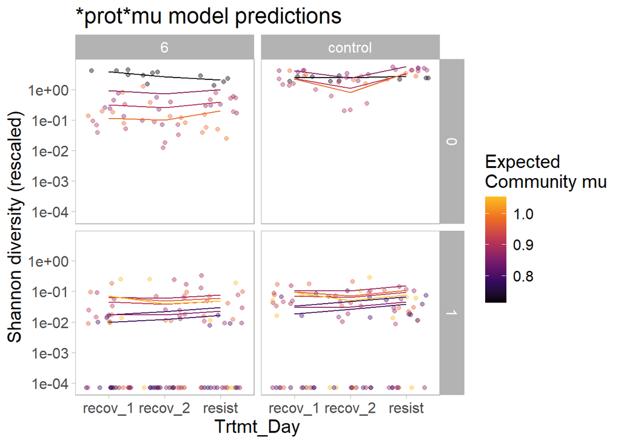

```r
print(plot_model_pred.MU(mod_list=div_mods6h, mod_name="*prot*mu"))
```

```r
####################
# 12h heat duration
####################
# grab just the treatment with its associated control data
diversity_12h <- rbind(diversity_forFit %>% filter(Heat == "12", Day > 1),
                       diversity_forFit %>% filter(Heat == "control", Day > 1, Day != 5))
# create a column for last day of heat, first day of recovery, and last day of recovery
diversity_12h$Trtmt_Day <- "resist"
diversity_12h$Trtmt_Day[diversity_12h$Day == 3] <- "recov_1"
diversity_12h$Trtmt_Day[diversity_12h$Day == 4] <- "recov_2"

# fit different models:
div_mods12h <- fit_diversity_models(diversity_12h)

# check the simplest possible models for multicolinearity
check_collinearity(div_mods12h[["simple"]])
```

| Term | VIF | VIF_CI_low | VIF_CI_high | SE_factor | Tolerance | Tolerance_CI_low | Tolerance_CI_high |
| --- | --- | --- | --- | --- | --- | --- | --- |
| CommRich | 1.084892 | 1.018041 | 1.399466 | 1.041581 | 0.9217508 | 0.7145583212 | 0.9822790 |
| Heat | 1.079071 | 1.015243 | 1.410165 | 1.038784 | 0.9267228 | 0.7091369467 | 0.9849855 |
| Trtmt_Day | 1.008861 | 1.000000 | 3578.430666 | 1.004421 | 0.9912165 | 0.0002794521 | 1.0000000 |
| protegens | 1.135039 | 1.046921 | 1.388641 | 1.065382 | 0.8810272 | 0.7201285300 | 0.9551819 |
| community_expected_mu | 1.051008 | 1.004498 | 1.578379 | 1.025187 | 0.9514678 | 0.6335614452 | 0.9955217 |

```r
check_collinearity(div_mods12h[["simple resist"]])
```

| Term | VIF | VIF_CI_low | VIF_CI_high | SE_factor | Tolerance | Tolerance_CI_low | Tolerance_CI_high |
| --- | --- | --- | --- | --- | --- | --- | --- |
| CommRich | 1.330315 | 1.187728 | 1.581200 | 1.153393 | 0.7517019 | 0.632430943 | 0.8419434 |
| Heat | 1.018253 | 1.000031 | 11.793014 | 1.009085 | 0.9820742 | 0.084795967 | 0.9999691 |
| Trtmt_Day | 1.008823 | 1.000000 | 3762.708374 | 1.004402 | 0.9912538 | 0.000265766 | 1.0000000 |
| community_expected_mu | 2.694996 | 2.266914 | 3.267724 | 1.641644 | 0.3710581 | 0.306023388 | 0.4411284 |
| resistant | 3.069439 | 2.565459 | 3.735669 | 1.751981 | 0.3257924 | 0.267689662 | 0.3897938 |

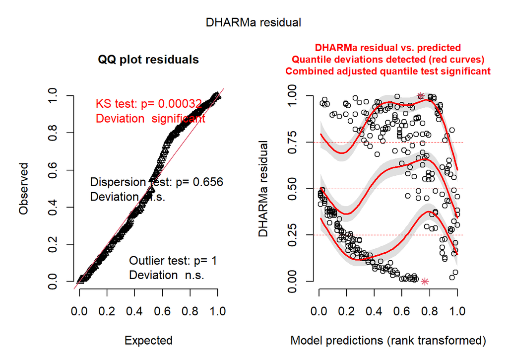

```
## Object of Class DHARMa with simulated residuals based on 250 simulations with refit = FALSE . See ?DHARMa::simulateResiduals for help.
##
## Scaled residual values: 0.696 0.028 0.964 0.224 0.628 0.356 0.42 0.992 0.072 0.104 0.252 0.46 0.22 0.02 0.744 0.364 0.82 0.828 0.376 0.208 ...
```

```r
# check the fit of the overall preferred model
simulateResiduals(fittedModel = div_mods12h[["*prot + prot*mu"]], plot = TRUE)
```

```r
summary(div_mods12h[["*prot + prot*mu"]])
```

```
##  Family: lognormal  ( log )
## Formula:
## Diversity_scalePLUSepsilon ~ CommRich + Heat * Trtmt_Day * protegens +
##     protegens * community_expected_mu
## Data: data_subset
##
##       AIC       BIC    logLik -2*log(L)  df.resid
##   -1461.6   -1403.3     746.8   -1493.6       266
##
##
## Dispersion parameter for lognormal family (): 1.58
##
## Conditional model:
##                                        Estimate Std. Error z value Pr(>|z|)
## (Intercept)                            -0.24192    0.79020  -0.306  0.75949
## CommRich                                0.89015    0.09009   9.881  < 2e-16 ***
## Heatcontrol                             2.86009    0.31085   9.201  < 2e-16 ***
## Trtmt_Dayrecov_2                        0.52184    0.38211   1.366  0.17204
## Trtmt_Dayresist                         0.96973    0.36672   2.644  0.00819 **
## protegens                              -9.17281    1.28869  -7.118 1.10e-12 ***
## community_expected_mu                  -4.69674    0.83311  -5.638 1.72e-08 ***
## Heatcontrol:Trtmt_Dayrecov_2           -0.56773    0.41311  -1.374  0.16935
## Heatcontrol:Trtmt_Dayresist            -0.66119    0.39557  -1.672  0.09462 .
## Heatcontrol:protegens                  -2.20145    0.44028  -5.000 5.73e-07 ***
## Trtmt_Dayrecov_2:protegens             -0.18892    0.48935  -0.386  0.69945
## Trtmt_Dayresist:protegens              -0.92594    0.47977  -1.930  0.05361 .
## protegens:community_expected_mu         8.80168    1.37591   6.397 1.58e-10 ***
## Heatcontrol:Trtmt_Dayrecov_2:protegens -0.41540    0.61712  -0.673  0.50087
## Heatcontrol:Trtmt_Dayresist:protegens   0.72654    0.58996   1.232  0.21813
## ---
## Signif. codes:  0 '***' 0.001 '**' 0.01 '*' 0.05 '.' 0.1 ' ' 1
```

```r
# print a summary table of the model fits
data.frame(pars = sapply(div_mods12h, npar_of_glmmTMB_fit),
                           AIC = sapply(div_mods12h, AIC),
                           AICc = sapply(div_mods12h, AICc),
                           BIC = sapply(div_mods12h, BIC)) %>%
                    mutate(dAIC = min(AIC)-AIC,
                           dAICc = min(AICc)-AICc,
                           dBIC = min(BIC)-BIC) %>% arrange(BIC)
```

|  | pars | AIC | AICc | BIC | dAIC | dAICc | dBIC |
| --- | --- | --- | --- | --- | --- | --- | --- |
| *prot*mu | 26 | -1537.222 | -1531.716 | -1442.533 | 0.00000 | 0.0000 | 0.00000 |
| *prot + prot*mu | 16 | -1461.611 | -1459.558 | -1403.341 | -75.61125 | -72.1582 | -39.19218 |
| *prot | 14 | -1427.601 | -1426.028 | -1376.614 | -109.62177 | -105.6889 | -65.91888 |
| *prot +mu | 15 | -1426.101 | -1424.296 | -1371.472 | -111.12174 | -107.4204 | -71.06076 |
| *mu + mu*prot | 16 | -1425.555 | -1423.503 | -1367.285 | -111.66688 | -108.2138 | -75.24781 |
| simple | 8 | -1368.121 | -1367.593 | -1338.986 | -169.10140 | -164.1230 | -103.54708 |
| +prot | 9 | -1367.436 | -1366.775 | -1334.659 | -169.78604 | -164.9419 | -107.87362 |
| +prot +mu | 10 | -1367.518 | -1366.706 | -1331.099 | -169.70414 | -165.0101 | -111.43363 |
| *mu +prot | 15 | -1372.644 | -1370.839 | -1318.015 | -164.57868 | -160.8773 | -124.51770 |
| simple resist | 8 | -1329.533 | -1329.005 | -1300.398 | -207.68949 | -202.7111 | -142.13517 |

[output cut: 12 more lines]

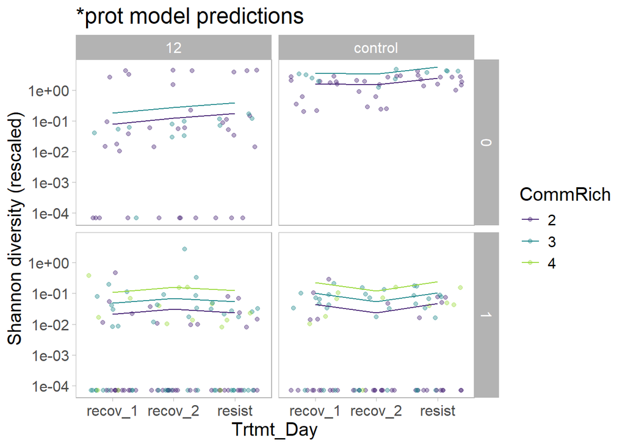

```r
# print some of the top model predictions
print(plot_model_pred.CommRich(mod_list=div_mods12h, mod_name="*prot"))
```

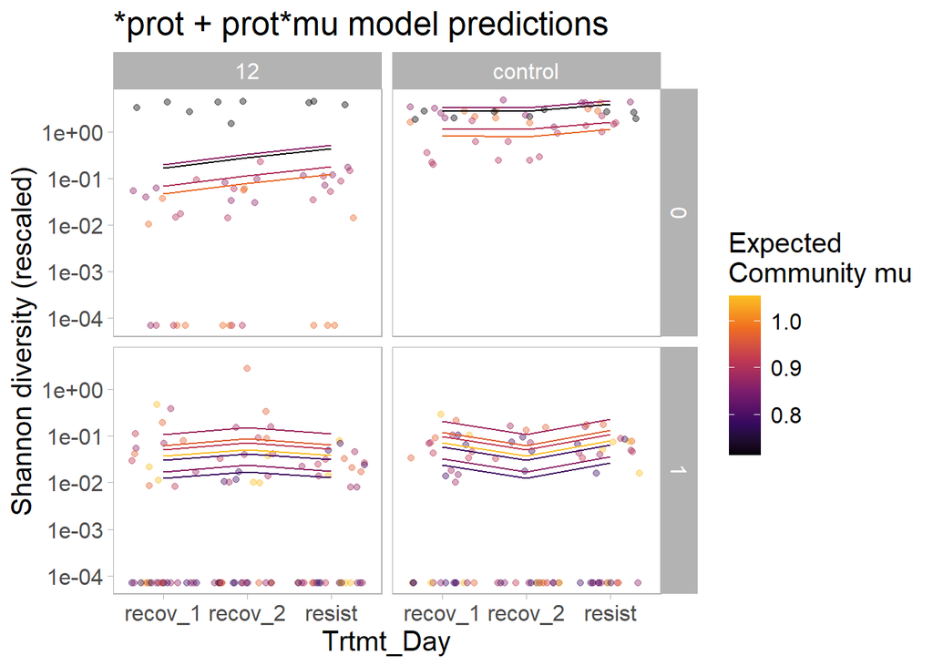

```r
print(plot_model_pred.MU(mod_list=div_mods12h, mod_name="*prot + prot*mu"))
```

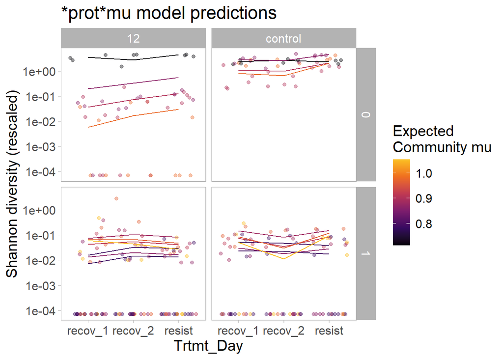

```r
print(plot_model_pred.MU(mod_list=div_mods12h, mod_name="*prot*mu"))
```

```r
####################
# 24h heat duration
####################
# grab just the treatment with its associated control data
diversity_24h <- rbind(diversity_forFit %>% filter(Heat == "24", Day > 1),
                       diversity_forFit %>% filter(Heat == "control", Day > 1, Day != 5))
# create a column for last day of heat, first day of recovery, and last day of recovery
diversity_24h$Trtmt_Day <- "resist"
diversity_24h$Trtmt_Day[diversity_24h$Day == 3] <- "recov_1"
diversity_24h$Trtmt_Day[diversity_24h$Day == 4] <- "recov_2"

# fit different models:
div_mods24h <- fit_diversity_models(diversity_24h)

# check the simplest possible models for multicolinearity
check_collinearity(div_mods24h[["simple"]])
```

| Term | VIF | VIF_CI_low | VIF_CI_high | SE_factor | Tolerance | Tolerance_CI_low | Tolerance_CI_high |
| --- | --- | --- | --- | --- | --- | --- | --- |
| CommRich | 1.126262 | 1.040481 | 1.393815 | 1.061255 | 0.8878931 | 0.7174554 | 0.9610940 |
| Heat | 1.110376 | 1.031052 | 1.392339 | 1.053744 | 0.9005960 | 0.7182158 | 0.9698834 |
| Trtmt_Day | 1.071204 | 1.011311 | 1.448235 | 1.034990 | 0.9335290 | 0.6904956 | 0.9888154 |
| protegens | 1.231330 | 1.112035 | 1.477651 | 1.109653 | 0.8121297 | 0.6767500 | 0.8992520 |
| community_expected_mu | 1.031109 | 1.000620 | 2.560680 | 1.015435 | 0.9698296 | 0.3905212 | 0.9993803 |

```r
check_collinearity(div_mods24h[["simple resist"]])
```

| Term | VIF | VIF_CI_low | VIF_CI_high | SE_factor | Tolerance | Tolerance_CI_low | Tolerance_CI_high |
| --- | --- | --- | --- | --- | --- | --- | --- |
| CommRich | 1.399518 | 1.238389 | 1.669557 | 1.183012 | 0.7145317 | 0.5989614 | 0.8075010 |
| Heat | 1.049369 | 1.003847 | 1.633568 | 1.024387 | 0.9529540 | 0.6121568 | 0.9961679 |
| Trtmt_Day | 1.045009 | 1.002801 | 1.723361 | 1.022257 | 0.9569299 | 0.5802616 | 0.9972073 |
| community_expected_mu | 2.741945 | 2.296717 | 3.340042 | 1.655882 | 0.3647046 | 0.2993974 | 0.4354040 |
| resistant | 3.167877 | 2.634792 | 3.874795 | 1.779853 | 0.3156688 | 0.2580782 | 0.3795366 |

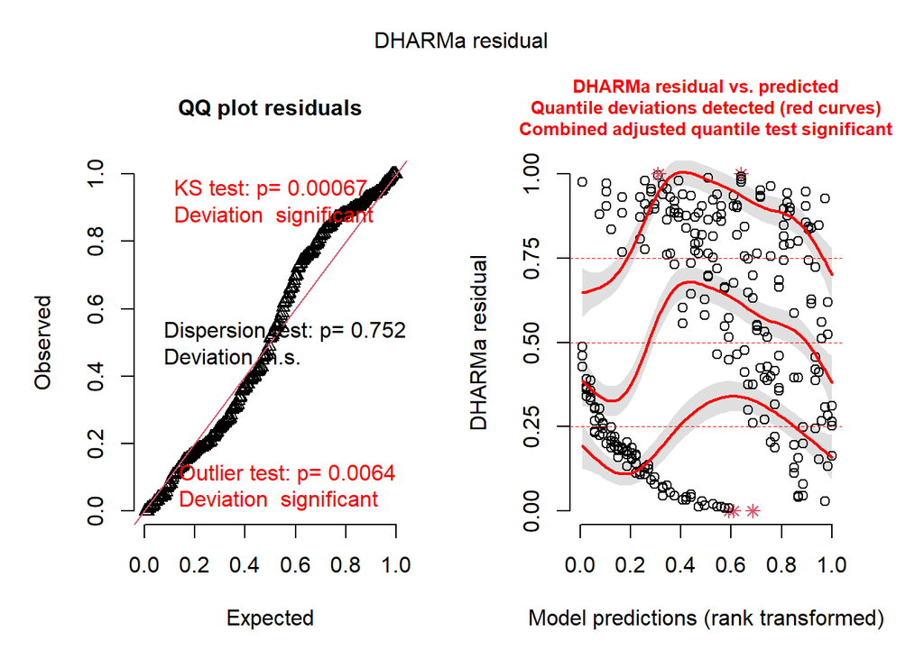

```
## Object of Class DHARMa with simulated residuals based on 250 simulations with refit = FALSE . See ?DHARMa::simulateResiduals for help.
##
## Scaled residual values: 0.848 0.46 0.116 0.808 0.356 0.788 0.304 0.328 0.2 0.872 0.076 0.152 0.164 0 0.932 0.364 0.744 0.232 0.98 0.956 ...
```

```r
# check the fit of the overall preferred model
simulateResiduals(fittedModel = div_mods24h[["*prot + prot*mu"]], plot = TRUE)
```

```r
summary(div_mods24h[["*prot + prot*mu"]])
```

```
##  Family: lognormal  ( log )
## Formula:
## Diversity_scalePLUSepsilon ~ CommRich + Heat * Trtmt_Day * protegens +
##     protegens * community_expected_mu
## Data: data_subset
##
##       AIC       BIC    logLik -2*log(L)  df.resid
##    -998.3    -940.7     515.2   -1030.3       254
##
##
## Dispersion parameter for lognormal family (): 1.35
##
## Conditional model:
##                                        Estimate Std. Error z value Pr(>|z|)
## (Intercept)                            -1.93414    0.81224  -2.381  0.01725 *
## CommRich                                0.89152    0.07867  11.333  < 2e-16 ***
## Heatcontrol                             2.28475    0.27144   8.417  < 2e-16 ***
## Trtmt_Dayrecov_2                       -1.19430    0.38527  -3.100  0.00194 **
## Trtmt_Dayresist                         1.99389    0.28818   6.919 4.55e-12 ***
## protegens                              -5.22837    1.23774  -4.224 2.40e-05 ***
## community_expected_mu                  -2.11575    0.83966  -2.520  0.01174 *
## Heatcontrol:Trtmt_Dayrecov_2            1.11271    0.41613   2.674  0.00750 **
## Heatcontrol:Trtmt_Dayresist            -1.57427    0.30765  -5.117 3.10e-07 ***
## Heatcontrol:protegens                  -3.49509    0.38270  -9.133  < 2e-16 ***
## Trtmt_Dayrecov_2:protegens              0.32389    0.46735   0.693  0.48829
## Trtmt_Dayresist:protegens              -3.56825    0.40387  -8.835  < 2e-16 ***
## protegens:community_expected_mu         5.70594    1.28980   4.424 9.69e-06 ***
## Heatcontrol:Trtmt_Dayrecov_2:protegens -0.89510    0.59839  -1.496  0.13469
## Heatcontrol:Trtmt_Dayresist:protegens   3.25067    0.51526   6.309 2.81e-10 ***
## ---
## Signif. codes:  0 '***' 0.001 '**' 0.01 '*' 0.05 '.' 0.1 ' ' 1
```

```r
# print a summary table of the model fits
data.frame(pars = sapply(div_mods24h, npar_of_glmmTMB_fit),
                           AIC = sapply(div_mods24h, AIC),
                           AICc = sapply(div_mods24h, AICc),
                           BIC = sapply(div_mods24h, BIC)) %>%
                    mutate(dAIC = min(AIC)-AIC,
                           dAICc = min(AICc)-AICc,
                           dBIC = min(BIC)-BIC) %>% arrange(BIC)
```

|  | pars | AIC | AICc | BIC | dAIC | dAICc | dBIC |
| --- | --- | --- | --- | --- | --- | --- | --- |
| *prot*mu | 26 | -1069.0157 | -1063.2379 | -975.4567 | 0.00000 | 0.00000 | 0.00000 |
| *prot + prot*mu | 16 | -998.3117 | -996.1615 | -940.7369 | -70.70397 | -67.07639 | -34.71975 |
| *prot | 14 | -982.9949 | -981.3478 | -932.6170 | -86.02077 | -81.89005 | -42.83971 |
| *prot +mu | 15 | -981.6001 | -979.7103 | -927.6238 | -87.41556 | -83.52754 | -47.83291 |
| *mu + mu*prot | 16 | -856.2231 | -854.0729 | -798.6483 | -212.79259 | -209.16501 | -176.80837 |
| simple | 8 | -820.8022 | -820.2505 | -792.0149 | -248.21342 | -242.98737 | -183.44183 |
| +prot | 9 | -821.8337 | -821.1414 | -789.4479 | -247.18195 | -242.09648 | -186.00877 |
| +prot +mu | 10 | -819.8351 | -818.9857 | -783.8509 | -249.18055 | -244.25220 | -191.60580 |
| *mu +prot | 15 | -828.2081 | -826.3183 | -774.2318 | -240.80754 | -236.91953 | -201.22490 |
| *resist + resist*mu | 16 | -818.5684 | -816.4182 | -760.9936 | -250.44729 | -246.81971 | -214.46307 |

[output cut: 12 more lines]

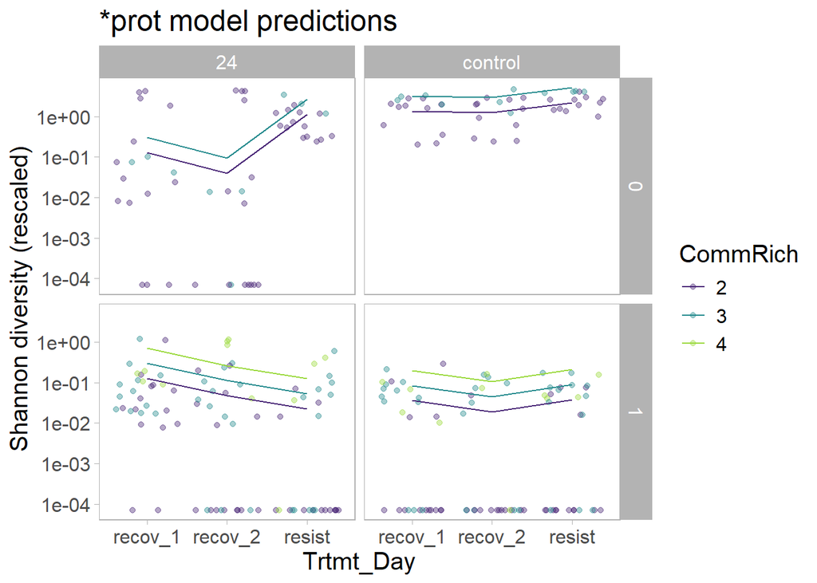

```r
# print some of the top model predictions
print(plot_model_pred.CommRich(mod_list=div_mods24h, mod_name="*prot"))
```

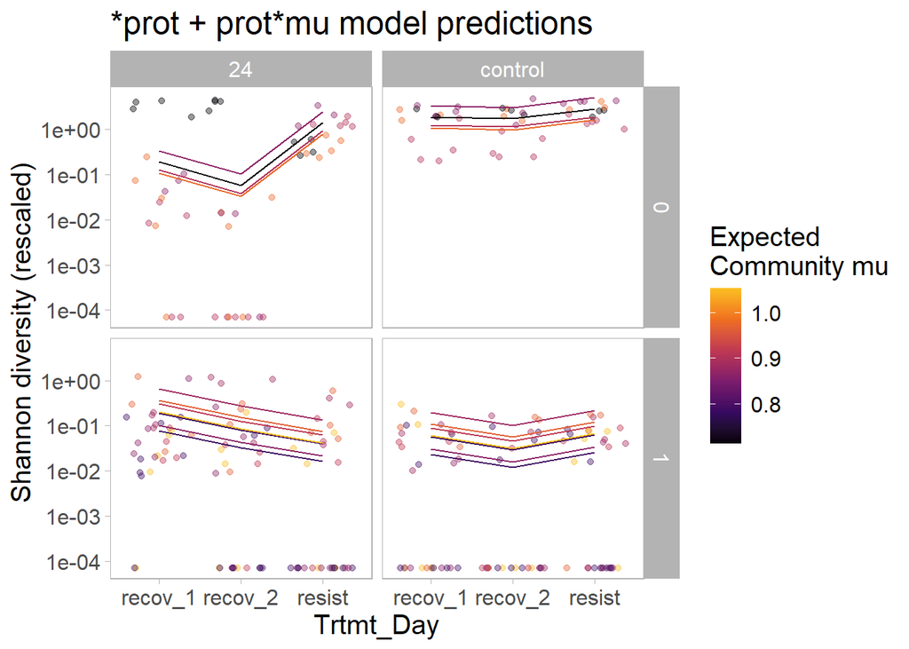

```r
print(plot_model_pred.MU(mod_list=div_mods24h, mod_name="*prot + prot*mu"))
```

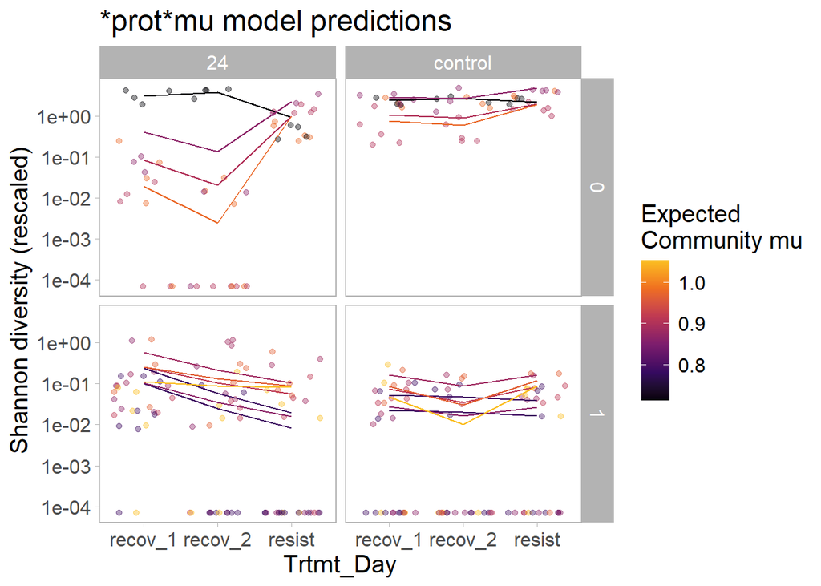

```r
print(plot_model_pred.MU(mod_list=div_mods24h, mod_name="*prot*mu"))
```

```r
####################
# 48h heat duration
####################
# grab just the treatment with its associated control data
diversity_48h <- rbind(diversity_forFit %>% filter(Heat == "48", Day > 2),
                       diversity_forFit %>% filter(Heat == "control", Day > 2))
# create a column for last day of heat, first day of recovery, and last day of recovery
diversity_48h$Trtmt_Day <- "resist"
diversity_48h$Trtmt_Day[diversity_48h$Day == 4] <- "recov_1"
diversity_48h$Trtmt_Day[diversity_48h$Day == 5] <- "recov_2"

# fit different models:
div_mods48h <- fit_diversity_models(diversity_48h)
```

```
## dropping columns from rank-deficient conditional model: Heatcontrol:Trtmt_Dayresist:protegens:community_expected_mu
```

```r
# check the simplest possible models for multicolinearity
check_collinearity(div_mods48h[["simple"]])
```

| Term | VIF | VIF_CI_low | VIF_CI_high | SE_factor | Tolerance | Tolerance_CI_low | Tolerance_CI_high |
| --- | --- | --- | --- | --- | --- | --- | --- |
| CommRich | 1.083789 | 1.015116 | 1.464433 | 1.041052 | 0.9226892 | 0.6828580 | 0.9851088 |
| Heat | 1.324303 | 1.173631 | 1.605721 | 1.150784 | 0.7551144 | 0.6227731 | 0.8520563 |
| Trtmt_Day | 1.110575 | 1.028460 | 1.429621 | 1.053838 | 0.9004344 | 0.6994859 | 0.9723280 |
| protegens | 1.239347 | 1.112019 | 1.511407 | 1.113260 | 0.8068764 | 0.6616352 | 0.8992656 |
| community_expected_mu | 1.035831 | 1.000908 | 2.414438 | 1.017758 | 0.9654088 | 0.4141751 | 0.9990932 |

```r
check_collinearity(div_mods48h[["simple resist"]])
```

| Term | VIF | VIF_CI_low | VIF_CI_high | SE_factor | Tolerance | Tolerance_CI_low | Tolerance_CI_high |
| --- | --- | --- | --- | --- | --- | --- | --- |
| CommRich | 1.519370 | 1.320603 | 1.841370 | 1.232627 | 0.6581674 | 0.5430740 | 0.7572299 |
| Heat | 1.145060 | 1.048626 | 1.432742 | 1.070075 | 0.8733168 | 0.6979626 | 0.9536291 |
| Trtmt_Day | 1.083869 | 1.015152 | 1.464227 | 1.041090 | 0.9226211 | 0.6829543 | 0.9850742 |
| community_expected_mu | 2.857075 | 2.359389 | 3.536968 | 1.690288 | 0.3500084 | 0.2827280 | 0.4238386 |
| resistant | 3.375061 | 2.763832 | 4.198102 | 1.837134 | 0.2962910 | 0.2382029 | 0.3618165 |

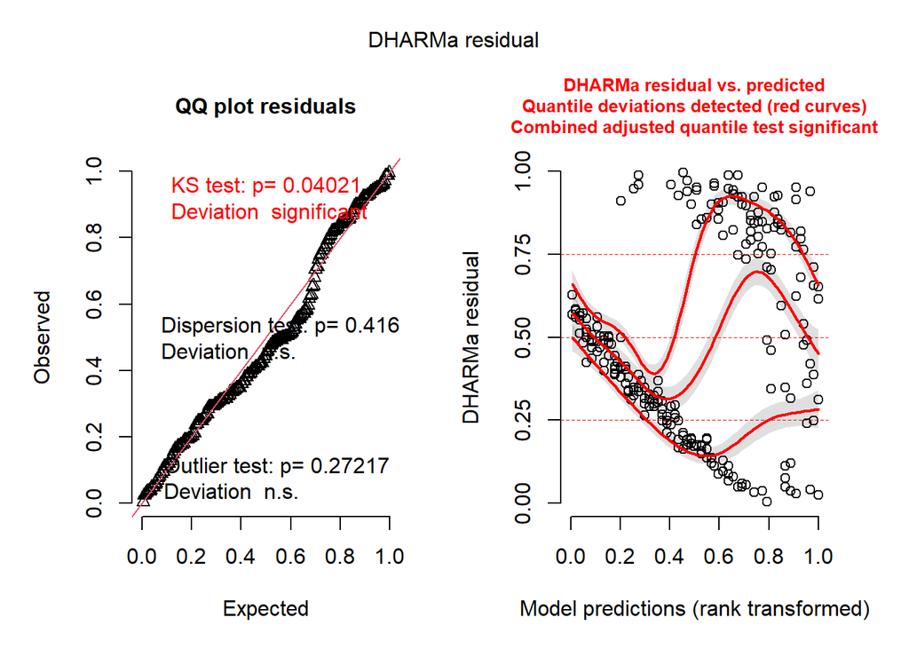

```
## Object of Class DHARMa with simulated residuals based on 250 simulations with refit = FALSE . See ?DHARMa::simulateResiduals for help.
##
## Scaled residual values: 0.504 0.468 0.484 0.628 0.368 0.312 0.172 0.572 0.492 0.552 0.412 0.5 0.468 0.4 0.456 0.2 0.24 0.312 0.312 0.904 ...
```

```r
# check the fit of the overall preferred model
simulateResiduals(fittedModel = div_mods48h[["*prot + prot*mu"]], plot = TRUE)
```

```r
summary(div_mods48h[["*prot + prot*mu"]])
```

```
##  Family: lognormal  ( log )
## Formula:
## Diversity_scalePLUSepsilon ~ CommRich + Heat * Trtmt_Day * protegens +
##     protegens * community_expected_mu
## Data: data_subset
##
##       AIC       BIC    logLik -2*log(L)  df.resid
##   -1801.9   -1746.8     917.0   -1833.9       216
##
##
## Dispersion parameter for lognormal family (): 1.21
##
## Conditional model:
##                                          Estimate Std. Error z value Pr(>|z|)
## (Intercept)                            -3.618e+00  8.944e-01  -4.045 5.24e-05
## CommRich                                7.245e-01  9.371e-02   7.731 1.07e-14
## Heatcontrol                             4.922e+00  3.864e-01  12.739  < 2e-16
## Trtmt_Dayrecov_2                       -9.450e-07  5.210e-01   0.000  1.00000
## Trtmt_Dayresist                        -5.184e-01  1.529e+00  -0.339  0.73463
## protegens                              -3.822e+00  1.453e+00  -2.631  0.00851
## community_expected_mu                  -2.871e+00  9.902e-01  -2.900  0.00373
## Heatcontrol:Trtmt_Dayrecov_2            1.838e-01  5.434e-01   0.338  0.73519
## Heatcontrol:Trtmt_Dayresist             5.907e-01  1.537e+00   0.384  0.70077
## Heatcontrol:protegens                  -4.332e+00  5.327e-01  -8.133 4.20e-16
## Trtmt_Dayrecov_2:protegens              1.906e-01  6.327e-01   0.301  0.76318
## Trtmt_Dayresist:protegens               1.571e-01  1.618e+00   0.097  0.92266
## protegens:community_expected_mu         4.490e+00  1.554e+00   2.890  0.00386
## Heatcontrol:Trtmt_Dayrecov_2:protegens  2.414e-01  7.330e-01   0.329  0.74195
## Heatcontrol:Trtmt_Dayresist:protegens   4.047e-01  1.661e+00   0.244  0.80748
##
## (Intercept)                            ***
## CommRich                               ***
## Heatcontrol                            ***
## Trtmt_Dayrecov_2
## Trtmt_Dayresist
## protegens                              **
## community_expected_mu                  **
## Heatcontrol:Trtmt_Dayrecov_2
## Heatcontrol:Trtmt_Dayresist
## Heatcontrol:protegens                  ***
## Trtmt_Dayrecov_2:protegens
## Trtmt_Dayresist:protegens
## protegens:community_expected_mu        **
## Heatcontrol:Trtmt_Dayrecov_2:protegens
## Heatcontrol:Trtmt_Dayresist:protegens
## ---
## Signif. codes:  0 '***' 0.001 '**' 0.01 '*' 0.05 '.' 0.1 ' ' 1
```

```r
# print a summary table of the model fits
data.frame(pars = sapply(div_mods48h, npar_of_glmmTMB_fit),
           AIC = sapply(div_mods48h, AIC),
           AICc = sapply(div_mods48h, AICc),
           BIC = sapply(div_mods48h, BIC)) %>%
                    mutate(dAIC = min(AIC)-AIC,
                           dAICc = min(AICc)-AICc,
                           dBIC = min(BIC)-BIC) %>% arrange(BIC)
```

|  | pars | AIC | AICc | BIC | dAIC | dAICc | dBIC |
| --- | --- | --- | --- | --- | --- | --- | --- |
| *prot | 14 | -1798.324 | -1796.389 | -1750.070 | -3.616341 | -3.021592 | 0.000000 |
| *prot + prot*mu | 16 | -1801.941 | -1799.411 | -1746.793 | 0.000000 | 0.000000 | -3.277134 |
| *prot +mu | 15 | -1796.627 | -1794.405 | -1744.926 | -5.313722 | -5.005712 | -5.144119 |
| *prot*mu | 25 | -1790.995 | -1784.684 | -1704.827 | -10.945811 | -14.726258 | -45.243582 |
| simple | 8 | -1666.823 | -1666.178 | -1639.249 | -135.117460 | -133.232968 | -110.820696 |
| +prot | 9 | -1666.179 | -1665.368 | -1635.158 | -135.761796 | -134.042374 | -114.911769 |
| +prot +mu | 10 | -1664.270 | -1663.275 | -1629.803 | -137.670618 | -136.135861 | -120.267328 |
| *mu + mu*prot | 16 | -1666.759 | -1664.228 | -1611.611 | -135.182236 | -135.182236 | -138.459370 |
| *mu +prot | 15 | -1661.632 | -1659.410 | -1609.931 | -140.308972 | -140.000962 | -140.139369 |
| simple resist | 8 | -1626.640 | -1625.994 | -1599.066 | -175.300592 | -173.416099 | -151.003827 |

[output cut: 12 more lines]